# Analyse des données comportementales

### d) Score de machiavélisme (DDS)

#### Modèle minimal

Création

```r
modele_machia_min = lm(datag$Machiavelisme_DDS ~ 1, data = datas) # Création du modèle de régression linéaire multiple minimal (aucune variable explicative)
```

Résumé

```r
summary(modele_machia_min) # Résumé du modèle
```

```
##
## Call:
## lm(formula = datag$Machiavelisme_DDS ~ 1, data = datas)
##
## Residuals:
##     Min      1Q  Median      3Q     Max
## -5.6286 -3.1286 -0.6286  2.3714 12.3714
##
## Coefficients:
##             Estimate Std. Error t value Pr(>|t|)
## (Intercept)   9.6286     0.7682   12.54 2.67e-14 ***
## ---
## Signif. codes:  0 '***' 0.001 '**' 0.01 '*' 0.05 '.' 0.1 ' ' 1
##
## Residual standard error: 4.544 on 34 degrees of freedom
```

#### Modèle maximal

```r
modele_machia_max = lm(datag$Machiavelisme_DDS ~ ., data = datas) # Création du modèle de régression linéaire multiple maximal (toutes les variables explicatives)
alias(modele_machia_max) # Résumé du modèle
```

Résumé

```r
summary(modele_machia_max) # Résumé du modèle
```

```
##
## Call:
## lm(formula = datag$Machiavelisme_DDS ~ ., data = datas)
##
## Residuals:
##     Min      1Q  Median      3Q     Max
## -3.9348 -0.8179  0.0335  0.8116  3.5781
##
## Coefficients:
##                  Estimate Std. Error t value Pr(>|t|)
## (Intercept)      49.75933   19.84611   2.507   0.0461 *
## Sexe              4.80457    3.25580   1.476   0.1905
## Age              -1.06818    0.57941  -1.844   0.1148
## Haut_visage      -7.70261    3.85816  -1.996   0.0929 .
## Bas_visage        0.05965    1.12336   0.053   0.9594
## Clignements      -1.41195    2.23352  -0.632   0.5506
## Yeux              0.01400    1.22355   0.011   0.9912
## Tete              0.11868    0.78327   0.152   0.8845
## Buste             0.11475    1.18157   0.097   0.9258
## Bras             -5.01896    3.31770  -1.513   0.1811
## Mains            -0.53245    1.49068  -0.357   0.7332
## Jambes           -0.49683    0.66766  -0.744   0.4849
## Pieds            -0.62163    1.17565  -0.529   0.6160
## Self_Adaptators   1.04364    0.55162   1.892   0.1074
## Pas_P1_P2        -4.89431    3.30063  -1.483   0.1886
## Temps_P1_P2      -0.10994    2.02465  -0.054   0.9585
## Haut_visage2      0.39212    7.10212   0.055   0.9578
## Bas_visage2      -0.33585    1.09476  -0.307   0.7694
## Clignements2      0.36896    1.06723   0.346   0.7414
## Yeux2             0.30058    0.61872   0.486   0.6443
## Tete2            -0.44778    1.25392  -0.357   0.7332
## Buste2            0.40328    0.83913   0.481   0.6478
## Bras2             2.13474    4.30344   0.496   0.6375
## Mains2           -0.23093    1.12994  -0.204   0.8448
## Jambes2           0.40189    0.39292   1.023   0.3458
## Pieds2           -6.44301    2.59755  -2.480   0.0478 *
## Self_Adaptators2 -0.39591    0.27788  -1.425   0.2041
## Pas_P2_Cible      5.05454    2.21124   2.286   0.0623 .
## Temps_P2_Cible   -2.88813    2.52126  -1.146   0.2956
## ---
## Signif. codes:  0 '***' 0.001 '**' 0.01 '*' 0.05 '.' 0.1 ' ' 1
##
## Residual standard error: 3.659 on 6 degrees of freedom
## Multiple R-squared:  0.8856, Adjusted R-squared:  0.3516
## F-statistic: 1.658 on 28 and 6 DF,  p-value: 0.2744
```

#### Meilleur modèle

Nous allons utiliser la méthode ascendante avec l’AIC.

💡 *Retirer `results='hide'` pour afficher les détails.*

```r
modele_machia_best <- step(modele_machia_min, scope = list(lower = modele_machia_min, upper = modele_machia_max), data = datag, direction = "forward")  # Recherche du modèle minimisant l'AIC en partant du modèle minimal (en ajoutant des variables)
```

Meilleur modèle (AIC = 197.7)

```r
summary(modele_machia_best)
```

```
##
## Call:
## lm(formula = datag$Machiavelisme_DDS ~ Age + Bras2 + Self_Adaptators +
##     Clignements2 + Tete2 + Tete + Haut_visage + Bas_visage +
##     Pieds2, data = datas)
##
## Residuals:
##     Min      1Q  Median      3Q     Max
## -5.1927 -2.3912 -0.6153  2.0074  7.1430
##
## Coefficients:
##                 Estimate Std. Error t value Pr(>|t|)
## (Intercept)      25.4398     5.9665   4.264 0.000251 ***
## Age              -0.6822     0.2481  -2.750 0.010924 *
## Bras2            -4.7528     1.6003  -2.970 0.006491 **
## Self_Adaptators   0.2602     0.1557   1.671 0.107106
## Clignements2      0.2891     0.2692   1.074 0.293184
## Tete2            -0.7127     0.3918  -1.819 0.080911 .
## Tete              0.6602     0.4028   1.639 0.113731
## Haut_visage      -5.1087     2.6750  -1.910 0.067697 .
## Bas_visage       -0.6438     0.5079  -1.268 0.216614
## Pieds2           -1.6101     1.3071  -1.232 0.229473
## ---
## Signif. codes:  0 '***' 0.001 '**' 0.01 '*' 0.05 '.' 0.1 ' ' 1
##
## Residual standard error: 3.523 on 25 degrees of freedom
## Multiple R-squared:  0.5581, Adjusted R-squared:  0.399
## F-statistic: 3.508 on 9 and 25 DF,  p-value: 0.006225
```

```r
tbl_regression(modele_machia_best,
               estimate_fun = purrr::partial(style_ratio, digits = 3), # Nombre de décimales des coefficients
               pvalue_fun = purrr::partial(style_sigfig, digits = 4)) %>% # Nombre de décimale des p-valeurs
  modify_caption("<center><b>Modèle de régression linéaire multiple le plus performant (AIC = 197.7) pour prédire le <i>score de machiavélisme (DDS)</i> et expliquant 39.9% de la variance des données.</b></center.7>") %>% # Légende
  modify_header(label = "**Variable**", p.value = "**p-valeur**") %>% # Entête
  modify_footnote(std.error = "SE = Erreur Type", ci = "CI = Intervalle de Confiance", abbreviation = TRUE)  %>% # Abbréviations
  add_significance_stars(hide_ci = FALSE,
                         hide_p = FALSE,
                         pattern = "{p.value}{stars}") %>% # Niveau de significativité
  add_glance_source_note(label = list(sigma ~ "\U03C3", adj.r.squared ~ "R\xc2\xb2 ajusté",  r.squared ~ "R\xc2\xb2", p.value ~ "p-valeur"),
                         include = c(adj.r.squared, r.squared,AIC, p.value, sigma)) # Statistiques du modèle
```

**Modèle de régression linéaire multiple le plus performant (AIC = 197.7) pour prédire le *score de machiavélisme (DDS)* et expliquant 39.9% de la variance des données.**

| **Variable** | **Beta** | **SE**<sup>1</sup> | **95% CI**<sup>1</sup> | **p-valeur**<sup>2</sup> |
| --- | --- | --- | --- | --- |
| Age | -0.682 | 0.248 | 1.000, -0.171 | 0.0109* |
| Nombre de mouvements des bras à l'arrêt 2 | 1.000 | 1.60 | 1.000, 1.000 | 0.0065** |
| Nombre de self-adaptators à l'arrêt 1 | 0.260 | 0.156 | -0.060, 0.581 | 0.1071 |
| Nombre de clignements des yeux à l'arrêt 2 | 0.289 | 0.269 | -0.265, 0.844 | 0.2932 |
| Nombre de mouvements de la tête à l'arrêt 2 | -0.713 | 0.392 | 1.000, 0.094 | 0.0809 |
| Nombre de mouvements de la tête à l'arrêt 1 | 0.660 | 0.403 | -0.169, 1.490 | 0.1137 |
| Nombre de mouvements du haut du visage à l'arrêt 1 | 1.000 | 2.67 | 1.000, 0.401 | 0.0677 |
| Nombre de mouvements du bas du visage à l'arrêt 1 | -0.644 | 0.508 | 1.000, 0.402 | 0.2166 |
| Nombre de mouvements des pieds à l'arrêt 2 | 1.000 | 1.31 | 1.000, 1.082 | 0.2295 |

R² ajusté = 0.399; R² = 0.558; AIC = 198; p-valeur = 0.0062; σ = 3.52  
<sup>1</sup> SE = Erreur Type, CI = Intervalle de Confiance  
<sup>2</sup> *p<0.05; **p<0.01; ***p<0.001

Analyse de la Variance du modèle

```r
summary.aov(modele_machia_best) # Résumé
```

```
##                 Df Sum Sq Mean Sq F value  Pr(>F)
## Age              1 118.64  118.64   9.558 0.00484 **
## Bras2            1  49.32   49.32   3.973 0.05725 .
## Self_Adaptators  1  52.56   52.56   4.234 0.05019 .
## Clignements2     1  38.50   38.50   3.102 0.09044 .
## Tete2            1  41.88   41.88   3.374 0.07814 .
## Tete             1  26.14   26.14   2.106 0.15913
## Haut_visage      1  24.31   24.31   1.958 0.17399
## Bas_visage       1  21.67   21.67   1.746 0.19835
## Pieds2           1  18.84   18.84   1.517 0.22947
## Residuals       25 310.32   12.41
## ---
## Signif. codes:  0 '***' 0.001 '**' 0.01 '*' 0.05 '.' 0.1 ' ' 1
```

### e) Score de psychopathie (DDS)

#### Modèle minimal

Création

```r
modele_psycho_min = lm(datag$Psychopathie_DDS ~ 1, data = datas) # Création du modèle de régression linéaire multiple minimal (aucune variable explicative)
```

Résumé

```r
summary(modele_psycho_min) # Résumé du modèle
```

```
##
## Call:
## lm(formula = datag$Psychopathie_DDS ~ 1, data = datas)
##
## Residuals:
##     Min      1Q  Median      3Q     Max
## -5.7714 -3.2714 -0.7714  3.2286  9.2286
##
## Coefficients:
##             Estimate Std. Error t value Pr(>|t|)
## (Intercept)   10.771      0.738    14.6 3.33e-16 ***
## ---
## Signif. codes:  0 '***' 0.001 '**' 0.01 '*' 0.05 '.' 0.1 ' ' 1
##
## Residual standard error: 4.366 on 34 degrees of freedom
```

#### Modèle maximal

```r
modele_psycho_max = lm(datag$Psychopathie_DDS ~ ., data = datas) # Création du modèle de régression linéaire multiple maximal (toutes les variables explicatives)
alias(modele_psycho_max) # Résumé du modèle
```

Résumé

```r
summary(modele_psycho_max) # Résumé du modèle
```

```
##
## Call:
## lm(formula = datag$Psychopathie_DDS ~ ., data = datas)
##
## Residuals:
##     Min      1Q  Median      3Q     Max
## -2.5799 -0.9240 -0.1584  0.6340  3.9735
##
## Coefficients:
##                  Estimate Std. Error t value Pr(>|t|)
## (Intercept)       6.13680   18.83076   0.326   0.7556
## Sexe              4.45731    3.08923   1.443   0.1992
## Age              -1.21721    0.54976  -2.214   0.0688 .
## Haut_visage       5.72412    3.66077   1.564   0.1689
## Bas_visage       -0.13855    1.06589  -0.130   0.9008
## Clignements       2.90982    2.11925   1.373   0.2188
## Yeux             -1.66238    1.16096  -1.432   0.2021
## Tete             -0.64928    0.74319  -0.874   0.4159
## Buste            -0.56797    1.12112  -0.507   0.6305
## Bras             -4.17660    3.14796  -1.327   0.2328
## Mains             0.10015    1.41441   0.071   0.9459
## Jambes           -0.04529    0.63351  -0.071   0.9453
## Pieds             1.46102    1.11550   1.310   0.2382
## Self_Adaptators   0.74444    0.52340   1.422   0.2048
## Pas_P1_P2         5.23494    3.13176   1.672   0.1456
## Temps_P1_P2      -0.33723    1.92106  -0.176   0.8664
## Haut_visage2      5.57195    6.73877   0.827   0.4400
## Bas_visage2      -0.22788    1.03875  -0.219   0.8336
## Clignements2     -1.15208    1.01263  -1.138   0.2986
## Yeux2            -0.32500    0.58707  -0.554   0.5999
## Tete2             1.32361    1.18977   1.112   0.3085
## Buste2            0.35072    0.79620   0.440   0.6750
## Bras2            -4.35351    4.08327  -1.066   0.3274
## Mains2            0.83828    1.07213   0.782   0.4640
## Jambes2           0.04329    0.37282   0.116   0.9113
## Pieds2           -1.87275    2.46466  -0.760   0.4761
## Self_Adaptators2  0.10139    0.26366   0.385   0.7138
## Pas_P2_Cible      1.96009    2.09811   0.934   0.3862
## Temps_P2_Cible   -1.32344    2.39227  -0.553   0.6001
## ---
## Signif. codes:  0 '***' 0.001 '**' 0.01 '*' 0.05 '.' 0.1 ' ' 1
##
## Residual standard error: 3.472 on 6 degrees of freedom
## Multiple R-squared:  0.8884, Adjusted R-squared:  0.3676
## F-statistic: 1.706 on 28 and 6 DF,  p-value: 0.2617
```

#### Meilleur modèle

Nous allons utiliser la méthode ascendante avec l’AIC.

💡 *Retirer `results='hide'` pour afficher les détails.*

```r
modele_psycho_best <- step(modele_psycho_min, scope = list(lower = modele_psycho_min, upper = modele_psycho_max), data = datag, direction = "forward")  # Recherche du modèle minimisant l'AIC en partant du modèle minimal (en ajoutant des variables)
```

Meilleur modèle (AIC = 175.72)

```r
summary(modele_psycho_best)
```

```
##
## Call:
## lm(formula = datag$Psychopathie_DDS ~ Mains2 + Bas_visage + Tete +
##     Haut_visage + Temps_P1_P2 + Buste2 + Age + Sexe + Self_Adaptators +
##     Tete2 + Pas_P1_P2 + Bras + Yeux2 + Buste + Bas_visage2, data = datas)
##
## Residuals:
##     Min      1Q  Median      3Q     Max
## -4.3689 -0.9436  0.0078  0.8308  4.3493
##
## Coefficients:
##                 Estimate Std. Error t value Pr(>|t|)
## (Intercept)      24.4854     8.7484   2.799 0.011453 *
## Mains2            1.5071     0.3926   3.838 0.001108 **
## Bas_visage        0.4175     0.4746   0.880 0.390029
## Tete             -0.7791     0.2970  -2.623 0.016735 *
## Haut_visage       6.3392     1.9565   3.240 0.004309 **
## Temps_P1_P2      -0.3934     1.0368  -0.379 0.708588
## Buste2            0.3252     0.2430   1.338 0.196604
## Age              -1.1672     0.2678  -4.359 0.000338 ***
## Sexe              5.5433     1.4507   3.821 0.001153 **
## Self_Adaptators   0.4607     0.1526   3.018 0.007066 **
## Tete2            -0.1385     0.3373  -0.411 0.685957
## Pas_P1_P2         2.1231     0.7685   2.763 0.012393 *
## Bras             -2.5025     1.0098  -2.478 0.022766 *
## Yeux2            -0.2978     0.2224  -1.339 0.196317
## Buste             0.4433     0.3022   1.467 0.158739
## Bas_visage2      -0.4244     0.3880  -1.094 0.287674
## ---
## Signif. codes:  0 '***' 0.001 '**' 0.01 '*' 0.05 '.' 0.1 ' ' 1
##
## Residual standard error: 2.487 on 19 degrees of freedom
## Multiple R-squared:  0.8187, Adjusted R-squared:  0.6756
## F-statistic:  5.72 on 15 and 19 DF,  p-value: 0.0002793
```

```r
tbl_regression(modele_psycho_best,
               estimate_fun = purrr::partial(style_ratio, digits = 3), # Nombre de décimales des coefficients
               pvalue_fun = purrr::partial(style_sigfig, digits = 4)) %>% # Nombre de décimale des p-valeurs
  modify_caption("<center><b>Modèle de régression linéaire multiple le plus performant (AIC = 175.72) pour prédire le <i>score de psychopathie (DDS)</i> et expliquant 67.6% de la variance des données.</b></center>") %>% # Légende
  modify_header(label = "**Variable**", p.value = "**p-valeur**") %>% # Entête
  modify_footnote(std.error = "SE = Erreur Type", ci = "CI = Intervalle de Confiance", abbreviation = TRUE)  %>% # Abbréviations
  add_significance_stars(hide_ci = FALSE,
                         hide_p = FALSE,
                         pattern = "{p.value}{stars}") %>% # Niveau de significativité
  add_glance_source_note(label = list(sigma ~ "\U03C3", adj.r.squared ~ "R\xc2\xb2 ajusté",  r.squared ~ "R\xc2\xb2", p.value ~ "p-valeur"),
                         include = c(adj.r.squared, r.squared,AIC, p.value, sigma)) # Statistiques du modèle
```

**Modèle de régression linéaire multiple le plus performant (AIC = 175.72) pour prédire le *score de psychopathie (DDS)* et expliquant 67.6% de la variance des données.**

| **Variable** | **Beta** | **SE**<sup>1</sup> | **95% CI**<sup>1</sup> | **p-valeur**<sup>2</sup> |
| --- | --- | --- | --- | --- |
| Nombre de mouvements des mains à l'arrêt 2 | 1.507 | 0.393 | 0.685, 2.329 | 0.0011** |
| Nombre de mouvements du bas du visage à l'arrêt 1 | 0.417 | 0.475 | -0.576, 1.411 | 0.3900 |
| Nombre de mouvements de la tête à l'arrêt 1 | -0.779 | 0.297 | 1.000, -0.157 | 0.0167* |
| Nombre de mouvements du haut du visage à l'arrêt 1 | 6.339 | 1.96 | 2.244, 10.43 | 0.0043** |
| Temps entre l'arrêt 1 et l'arrêt 2 | -0.393 | 1.04 | 1.000, 1.777 | 0.7086 |
| Nombre de mouvements du buste à l'arrêt 2 | 0.325 | 0.243 | -0.183, 0.834 | 0.1966 |
| Age | 1.000 | 0.268 | 1.000, -0.607 | 0.0003*** |
| Sexe | 5.543 | 1.45 | 2.507, 8.580 | 0.0012** |
| Nombre de self-adaptators à l'arrêt 1 | 0.461 | 0.153 | 0.141, 0.780 | 0.0071** |
| Nombre de mouvements de la tête à l'arrêt 2 | -0.138 | 0.337 | -0.844, 0.567 | 0.6860 |
| Nombre de pas entre l'arrêt 1 et l'arrêt 2 | 2.123 | 0.769 | 0.515, 3.732 | 0.0124* |
| Nombre de mouvements des bras à l'arrêt 1 | 1.000 | 1.01 | 1.000, -0.389 | 0.0228* |
| Nombre de mouvements des yeux à l'arrêt 2 | -0.298 | 0.222 | -0.763, 0.168 | 0.1963 |
| Nombre de mouvements du buste à l'arrêt 1 | 0.443 | 0.302 | -0.189, 1.076 | 0.1587 |
| Nombre de mouvements du bas du visage à l'arrêt 2 | -0.424 | 0.388 | 1.000, 0.388 | 0.2877 |

R² ajusté = 0.676; R² = 0.819; AIC = 176; p-valeur = 0.0003; σ = 2.49  
<sup>1</sup> SE = Erreur Type, CI = Intervalle de Confiance  
<sup>2</sup> *p<0.05; **p<0.01; ***p<0.001

Analyse de la Variance du modèle

```r
summary.aov(modele_psycho_best) # Résumé
```

```
##                 Df Sum Sq Mean Sq F value   Pr(>F)
## Mains2           1 102.49  102.49  16.571 0.000652 ***
## Bas_visage       1 100.23  100.23  16.204 0.000723 ***
## Tete             1  41.07   41.07   6.639 0.018480 *
## Haut_visage      1  46.21   46.21   7.472 0.013201 *
## Temps_P1_P2      1  54.03   54.03   8.735 0.008122 **
## Buste2           1  25.86   25.86   4.181 0.054983 .
## Age              1  19.53   19.53   3.158 0.091550 .
## Sexe             1  32.59   32.59   5.270 0.033250 *
## Self_Adaptators  1  31.42   31.42   5.081 0.036196 *
## Tete2            1  12.90   12.90   2.085 0.165003
## Pas_P1_P2        1  12.58   12.58   2.034 0.170070
## Bras             1  21.83   21.83   3.529 0.075748 .
## Yeux2            1  13.58   13.58   2.196 0.154753
## Buste            1   8.93    8.93   1.444 0.244254
## Bas_visage2      1   7.40    7.40   1.197 0.287674
## Residuals       19 117.52    6.19
## ---
## Signif. codes:  0 '***' 0.001 '**' 0.01 '*' 0.05 '.' 0.1 ' ' 1
```

### f) Score de narcissisme (DDS)

#### Modèle minimal

Création

```r
modele_narci_min = lm(datag$Narcissisme_DDS ~ 1, data = datas) # Création du modèle de régression linéaire multiple minimal (aucune variable explicative)
```

Résumé

```r
summary(modele_narci_min) # Résumé du modèle
```

```
##
## Call:
## lm(formula = datag$Narcissisme_DDS ~ 1, data = datas)
##
## Residuals:
##     Min      1Q  Median      3Q     Max
## -8.8571 -3.8571 -0.8571  2.6429 12.1429
##
## Coefficients:
##             Estimate Std. Error t value Pr(>|t|)
## (Intercept)  12.8571     0.9633   13.35 4.48e-15 ***
## ---
## Signif. codes:  0 '***' 0.001 '**' 0.01 '*' 0.05 '.' 0.1 ' ' 1
##
## Residual standard error: 5.699 on 34 degrees of freedom
```

#### Modèle maximal

```r
modele_narci_max = lm(datag$Narcissisme_DDS ~ ., data = datas)  # Création du modèle de régression linéaire multiple maximal (toutes les variables explicatives)
alias(modele_narci_max) # Résumé du modèle
```

Résumé

```r
summary(modele_narci_max) # Résumé du modèle
```

```
##
## Call:
## lm(formula = datag$Narcissisme_DDS ~ ., data = datas)
##
## Residuals:
##     Min      1Q  Median      3Q     Max
## -3.0406 -1.2833  0.0133  1.0728  3.5602
##
## Coefficients:
##                  Estimate Std. Error t value Pr(>|t|)
## (Intercept)       8.52086   21.50449   0.396   0.7056
## Sexe              7.71443    3.52786   2.187   0.0714 .
## Age              -0.28303    0.62782  -0.451   0.6680
## Haut_visage       1.14853    4.18056   0.275   0.7927
## Bas_visage       -1.69342    1.21723  -1.391   0.2136
## Clignements       1.77996    2.42016   0.735   0.4898
## Yeux             -3.16333    1.32580  -2.386   0.0543 .
## Tete              0.40485    0.84872   0.477   0.6502
## Buste            -1.60495    1.28030  -1.254   0.2566
## Bras              3.66078    3.59493   1.018   0.3478
## Mains            -1.58370    1.61524  -0.980   0.3647
## Jambes            0.15662    0.72346   0.216   0.8358
## Pieds             0.17941    1.27389   0.141   0.8926
## Self_Adaptators   0.16104    0.59771   0.269   0.7966
## Pas_P1_P2         0.04366    3.57643   0.012   0.9907
## Temps_P1_P2       1.66716    2.19383   0.760   0.4761
## Haut_visage2      6.87442    7.69559   0.893   0.4061
## Bas_visage2       0.23355    1.18624   0.197   0.8504
## Clignements2      0.04688    1.15641   0.041   0.9690
## Yeux2            -0.25951    0.67042  -0.387   0.7121
## Tete2            -0.05613    1.35870  -0.041   0.9684
## Buste2            1.67954    0.90925   1.847   0.1142
## Bras2            -1.83607    4.66305  -0.394   0.7074
## Mains2           -1.40467    1.22436  -1.147   0.2950
## Jambes2          -0.12020    0.42575  -0.282   0.7872
## Pieds2           -0.84292    2.81461  -0.299   0.7747
## Self_Adaptators2  0.15517    0.30110   0.515   0.6247
## Pas_P2_Cible      2.16219    2.39602   0.902   0.4016
## Temps_P2_Cible   -1.51364    2.73194  -0.554   0.5996
## ---
## Signif. codes:  0 '***' 0.001 '**' 0.01 '*' 0.05 '.' 0.1 ' ' 1
##
## Residual standard error: 3.965 on 6 degrees of freedom
## Multiple R-squared:  0.9146, Adjusted R-squared:  0.5159
## F-statistic: 2.294 on 28 and 6 DF,  p-value: 0.1514
```

#### Meilleur modèle

Nous allons utiliser la méthode ascendante avec l’AIC.

💡 *Retirer `results='hide'` pour afficher les détails.*

```r
modele_narci_best <- step(modele_narci_min, scope = list(lower = modele_narci_min, upper = modele_narci_max), data = datag, direction = "forward") # Recherche du modèle minimisant l'AIC en partant du modèle minimal (en ajoutant des variables)
```

Meilleur modèle (AIC = 192.07)

```r
summary(modele_narci_best)
```

```
##
## Call:
## lm(formula = datag$Narcissisme_DDS ~ Yeux + Bas_visage + Haut_visage2 +
##     Bras + Temps_P1_P2 + Sexe + Mains + Buste2 + Mains2, data = datas)
##
## Residuals:
##    Min     1Q Median     3Q    Max
## -9.428 -1.801 -0.217  2.122  4.454
##
## Coefficients:
##              Estimate Std. Error t value Pr(>|t|)
## (Intercept)    5.4685     6.0790   0.900 0.376934
## Yeux          -1.9626     0.3534  -5.554 8.96e-06 ***
## Bas_visage    -1.8541     0.5369  -3.453 0.001985 **
## Haut_visage2   3.2578     2.3333   1.396 0.174918
## Bras           5.1711     1.1678   4.428 0.000164 ***
## Temps_P1_P2    2.3568     1.0461   2.253 0.033284 *
## Sexe           5.8796     1.4547   4.042 0.000445 ***
## Mains         -2.1876     0.9259  -2.363 0.026231 *
## Buste2         0.8850     0.2760   3.206 0.003661 **
## Mains2        -0.8190     0.5657  -1.448 0.160067
## ---
## Signif. codes:  0 '***' 0.001 '**' 0.01 '*' 0.05 '.' 0.1 ' ' 1
##
## Residual standard error: 3.251 on 25 degrees of freedom
## Multiple R-squared:  0.7608, Adjusted R-squared:  0.6747
## F-statistic: 8.835 on 9 and 25 DF,  p-value: 7.529e-06
```

```r
tbl_regression(modele_narci_best,
               estimate_fun = purrr::partial(style_ratio, digits = 3), # Nombre de décimales des coefficients
               pvalue_fun = purrr::partial(style_sigfig, digits = 4)) %>% # Nombre de décimale des p-valeurs
  modify_caption("<center><b>Modèle de régression linéaire multiple le plus performant (AIC = 192.07) pour prédire le <i>narcissisme (DDS)</i> et expliquant 67.47% de la variance des données.</b></center>") %>% # Légende
  modify_header(label = "**Variable**", p.value = "**p-valeur**") %>% # Entête
  modify_footnote(std.error = "SE = Erreur Type", ci = "CI = Intervalle de Confiance", abbreviation = TRUE)  %>% # Abbréviations
  add_significance_stars(hide_ci = FALSE,
                         hide_p = FALSE,
                         pattern = "{p.value}{stars}") %>% # Niveau de significativité
  add_glance_source_note(label = list(sigma ~ "\U03C3", adj.r.squared ~ "R\xc2\xb2 ajusté",  r.squared ~ "R\xc2\xb2", p.value ~ "p-valeur"),
                         include = c(adj.r.squared, r.squared,AIC, p.value, sigma)) # Statistiques du modèle
```

**Modèle de régression linéaire multiple le plus performant (AIC = 192.07) pour prédire le *narcissisme (DDS)* et expliquant 67.47% de la variance des données.**

| **Variable** | **Beta** | **SE**<sup>1</sup> | **95% CI**<sup>1</sup> | **p-valeur**<sup>2</sup> |
| --- | --- | --- | --- | --- |
| Nombre de mouvements des yeux à l'arrêt 1 | 1.000 | 0.353 | 1.000, 1.000 | 0.0000*** |
| Nombre de mouvements du bas du visage à l'arrêt 1 | 1.000 | 0.537 | 1.000, -0.748 | 0.0020** |
| Nombre de mouvements du haut du visage à l'arrêt 2 | 3.258 | 2.33 | 1.000, 8.063 | 0.1749 |
| Nombre de mouvements des bras à l'arrêt 1 | 5.171 | 1.17 | 2.766, 7.576 | 0.0002*** |
| Temps entre l'arrêt 1 et l'arrêt 2 | 2.357 | 1.05 | 0.202, 4.511 | 0.0333* |
| Sexe | 5.880 | 1.45 | 2.884, 8.876 | 0.0004*** |
| Nombre de mouvements des mains à l'arrêt 1 | 1.000 | 0.926 | 1.000, -0.281 | 0.0262* |
| Nombre de mouvements du buste à l'arrêt 2 | 0.885 | 0.276 | 0.317, 1.454 | 0.0037** |
| Nombre de mouvements des mains à l'arrêt 2 | -0.819 | 0.566 | 1.000, 0.346 | 0.1601 |

R² ajusté = 0.675; R² = 0.761; AIC = 192; p-valeur = 0.0000; σ = 3.25  
<sup>1</sup> SE = Erreur Type, CI = Intervalle de Confiance  
<sup>2</sup> *p<0.05; **p<0.01; ***p<0.001

Analyse de la Variance du modèle

```r
summary.aov(modele_narci_best) # Résumé
```

```
##              Df Sum Sq Mean Sq F value   Pr(>F)
## Yeux          1 177.75  177.75  16.823 0.000382 ***
## Bas_visage    1 185.47  185.47  17.554 0.000304 ***
## Haut_visage2  1 103.18  103.18   9.765 0.004464 **
## Bras          1  63.61   63.61   6.021 0.021454 *
## Temps_P1_P2   1  55.51   55.51   5.254 0.030593 *
## Sexe          1  60.23   60.23   5.701 0.024837 *
## Mains         1  72.64   72.64   6.875 0.014667 *
## Buste2        1  99.58   99.58   9.424 0.005101 **
## Mains2        1  22.15   22.15   2.096 0.160067
## Residuals    25 264.15   10.57
## ---
## Signif. codes:  0 '***' 0.001 '**' 0.01 '*' 0.05 '.' 0.1 ' ' 1
```

### g) Niveau d’arousal (ADCL)

#### Modèle minimal

Création

```r
modele_arous_min = lm(datag$Excitation_ADCL ~ 1, data = datas) # Création du modèle de régression linéaire multiple minimal (aucune variable explicative)
```

Résumé

```r
summary(modele_arous_min) # Résumé du modèle
```

```
##
## Call:
## lm(formula = datag$Excitation_ADCL ~ 1, data = datas)
##
## Residuals:
##     Min      1Q  Median      3Q     Max
## -3.0857 -2.0857 -0.0857  1.9143  5.9143
##
## Coefficients:
##             Estimate Std. Error t value Pr(>|t|)
## (Intercept)   9.0857     0.3876   23.44   <2e-16 ***
## ---
## Signif. codes:  0 '***' 0.001 '**' 0.01 '*' 0.05 '.' 0.1 ' ' 1
##
## Residual standard error: 2.293 on 34 degrees of freedom
```

#### Modèle maximal

```r
modele_arous_max = lm(datag$Excitation_ADCL ~ ., data = datas) # Création du modèle de régression linéaire multiple maximal (toutes les variables explicatives)
alias(modele_arous_max) # Résumé du modèle
```

Résumé

```r
summary(modele_arous_max) # Résumé du modèle
```

```
##
## Call:
## lm(formula = datag$Excitation_ADCL ~ ., data = datas)
##
## Residuals:
##     Min      1Q  Median      3Q     Max
## -2.7822 -0.6475  0.1578  0.7872  2.3110
##
## Coefficients:
##                  Estimate Std. Error t value Pr(>|t|)
## (Intercept)      12.55990   14.53392   0.864    0.421
## Sexe             -2.10115    2.38433  -0.881    0.412
## Age               0.27904    0.42432   0.658    0.535
## Haut_visage       1.14673    2.82545   0.406    0.699
## Bas_visage        0.37409    0.82267   0.455    0.665
## Clignements      -1.57075    1.63568  -0.960    0.374
## Yeux              0.09531    0.89605   0.106    0.919
## Tete              0.60477    0.57361   1.054    0.332
## Buste             0.40294    0.86530   0.466    0.658
## Bras             -0.91116    2.42965  -0.375    0.721
## Mains             1.49291    1.09167   1.368    0.220
## Jambes           -0.51096    0.48895  -1.045    0.336
## Pieds            -0.16156    0.86097  -0.188    0.857
## Self_Adaptators  -0.06848    0.40397  -0.170    0.871
## Pas_P1_P2        -1.63868    2.41715  -0.678    0.523
## Temps_P1_P2      -2.35905    1.48271  -1.591    0.163
## Haut_visage2     -1.29470    5.20110  -0.249    0.812
## Bas_visage2      -1.21506    0.80173  -1.516    0.180
## Clignements2      1.29498    0.78157   1.657    0.149
## Yeux2            -0.24791    0.45311  -0.547    0.604
## Tete2            -0.78533    0.91828  -0.855    0.425
## Buste2            0.16984    0.61452   0.276    0.792
## Bras2            -0.40022    3.15154  -0.127    0.903
## Mains2            0.05205    0.82749   0.063    0.952
## Jambes2           0.22933    0.28775   0.797    0.456
## Pieds2           -0.57959    1.90227  -0.305    0.771
## Self_Adaptators2 -0.01732    0.20350  -0.085    0.935
## Pas_P2_Cible     -0.80070    1.61936  -0.494    0.639
## Temps_P2_Cible    2.97867    1.84640   1.613    0.158
##
## Residual standard error: 2.68 on 6 degrees of freedom
## Multiple R-squared:  0.7589, Adjusted R-squared:  -0.3661
## F-statistic: 0.6746 on 28 and 6 DF,  p-value: 0.7797
```

#### Meilleur modèle

Nous allons utiliser la méthode ascendante avec l’AIC.

💡 *Retirer `results='hide'` pour afficher les détails.*

```r
modele_arous_best <- step(modele_arous_min, scope = list(lower = modele_arous_min, upper = modele_arous_max), data = datag, direction = "forward")  # Recherche du modèle minimisant l'AIC en partant du modèle minimal (en ajoutant des variables)
```

Meilleur modèle (AIC = 149.9)

```r
summary(modele_arous_best)
```

```
##
## Call:
## lm(formula = datag$Excitation_ADCL ~ Yeux2 + Bras + Mains + Haut_visage2 +
##     Clignements2 + Temps_P1_P2 + Sexe, data = datas)
##
## Residuals:
##    Min     1Q Median     3Q    Max
## -2.844 -1.263  0.271  1.181  3.612
##
## Coefficients:
##              Estimate Std. Error t value Pr(>|t|)
## (Intercept)   14.4022     2.7253   5.285 1.42e-05 ***
## Yeux2         -0.5327     0.1518  -3.509 0.001594 **
## Bras          -2.4812     0.6441  -3.852 0.000654 ***
## Mains          0.9589     0.3726   2.574 0.015864 *
## Haut_visage2   2.6273     1.1798   2.227 0.034490 *
## Clignements2   0.1908     0.1327   1.438 0.161999
## Temps_P1_P2   -0.6650     0.4777  -1.392 0.175221
## Sexe          -0.9032     0.6879  -1.313 0.200278
## ---
## Signif. codes:  0 '***' 0.001 '**' 0.01 '*' 0.05 '.' 0.1 ' ' 1
##
## Residual standard error: 1.813 on 27 degrees of freedom
## Multiple R-squared:  0.5032, Adjusted R-squared:  0.3745
## F-statistic: 3.908 on 7 and 27 DF,  p-value: 0.004596
```

```r
tbl_regression(modele_arous_best,
               estimate_fun = purrr::partial(style_ratio, digits = 3), # Nombre de décimales des coefficients
               pvalue_fun = purrr::partial(style_sigfig, digits = 4)) %>% # Nombre de décimale des p-valeurs
  modify_caption("<center><b>Modèle de régression linéaire multiple le plus performant (AIC = 149.9) pour prédire le <i>niveau d'arousal (ADCL)</i> et expliquant 37.4% de la variance des données.</b></center>") %>% # Légende
  modify_header(label = "**Variable**", p.value = "**p-valeur**") %>% # Entête
  modify_footnote(std.error = "SE = Erreur Type", ci = "CI = Intervalle de Confiance", abbreviation = TRUE)  %>% # Abbréviations
  add_significance_stars(hide_ci = FALSE,
                         hide_p = FALSE,
                         pattern = "{p.value}{stars}") %>% # Niveau de significativité
  add_glance_source_note(label = list(sigma ~ "\U03C3", adj.r.squared ~ "R\xc2\xb2 ajusté",  r.squared ~ "R\xc2\xb2", p.value ~ "p-valeur"),
                         include = c(adj.r.squared, r.squared,AIC, p.value, sigma)) # Statistiques du modèle
```

**Modèle de régression linéaire multiple le plus performant (AIC = 149.9) pour prédire le *niveau d'arousal (ADCL)* et expliquant 37.4% de la variance des données.**

| **Variable** | **Beta** | **SE**<sup>1</sup> | **95% CI**<sup>1</sup> | **p-valeur**<sup>2</sup> |
| --- | --- | --- | --- | --- |
| Nombre de mouvements des yeux à l'arrêt 2 | -0.533 | 0.152 | -0.844, -0.221 | 0.0016** |
| Nombre de mouvements des bras à l'arrêt 1 | 1.000 | 0.644 | 1.000, 1.000 | 0.0007*** |
| Nombre de mouvements des mains à l'arrêt 1 | 0.959 | 0.373 | 0.194, 1.723 | 0.0159* |
| Nombre de mouvements du haut du visage à l'arrêt 2 | 2.627 | 1.18 | 0.207, 5.048 | 0.0345* |
| Nombre de clignements des yeux à l'arrêt 2 | 0.191 | 0.133 | -0.081, 0.463 | 0.1620 |
| Temps entre l'arrêt 1 et l'arrêt 2 | -0.665 | 0.478 | 1.000, 0.315 | 0.1752 |
| Sexe | -0.903 | 0.688 | 1.000, 0.508 | 0.2003 |

R² ajusté = 0.374; R² = 0.503; AIC = 150; p-valeur = 0.0046; σ = 1.81  
<sup>1</sup> SE = Erreur Type, CI = Intervalle de Confiance  
<sup>2</sup> *p<0.05; **p<0.01; ***p<0.001

Analyse de la Variance du modèle

```r
summary.aov(modele_arous_best) # Résumé
```

```
##              Df Sum Sq Mean Sq F value Pr(>F)
## Yeux2         1  21.49  21.485   6.533 0.0165 *
## Bras          1  23.88  23.876   7.260 0.0120 *
## Mains         1  11.49  11.493   3.495 0.0724 .
## Haut_visage2  1  15.41  15.413   4.687 0.0394 *
## Clignements2  1   6.08   6.078   1.848 0.1852
## Temps_P1_P2   1   5.94   5.938   1.806 0.1902
## Sexe          1   5.67   5.668   1.724 0.2003
## Residuals    27  88.79   3.289
## ---
## Signif. codes:  0 '***' 0.001 '**' 0.01 '*' 0.05 '.' 0.1 ' ' 1
```

## 7. Indices non-verbaux pertinents et scores ciblés

### a) Préparation des données

```r
#datap <- data[,c('Sexe', 'Condition', 'Bas_visage', 'Haut_visage', 'Bras', 'Mains', 'Jambes', 'Haut_visage2', 'Pas_P2_Cible', 'EAFF_BES', 'Ecog_BES', 'Machiavelisme_DDS', 'Psychopathie_DDS', 'Narcissisme_DDS', 'Excitation_ADCL')] # Conserver les indices pertinents et les 5 scores cibles
datap <- data[,c('Sexe', 'Condition', 'Bas_visage', 'Haut_visage', 'Yeux', 'Bras', 'Mains', 'Jambes', 'Temps_P1_P2', 'Haut_visage2', 'Buste2', 'Pas_P2_Cible', 'EAFF_BES', 'Ecog_BES', 'Machiavelisme_DDS', 'Psychopathie_DDS', 'Narcissisme_DDS', 'Excitation_ADCL')] # Conserver les indices pertinents et les 5 scores cibles
datap <- copy_labels(datap, data) # Copie des étiquettes
```

### b) Mouvements du bas du visage à l’arrêt 1

#### Recherche du meilleur modèle

```r
modele_basvis1_min = lm(datap$Bas_visage ~ 1, data = datap) # Création du modèle de régression minimal
modele_basvis1_max = lm(datap$Bas_visage ~ datap$Sexe + datap$Condition + datap$EAFF_BES + datap$Ecog_BES + datap$Machiavelisme_DDS + datap$Psychopathie_DDS + datap$Excitation_ADCL + datap$Narcissisme_DDS, data = datap) # Création du modèle de régression maximal
summary(modele_basvis1_max) # Résumé du modèle
```

```
##
## Call:
## lm(formula = datap$Bas_visage ~ datap$Sexe + datap$Condition +
##     datap$EAFF_BES + datap$Ecog_BES + datap$Machiavelisme_DDS +
##     datap$Psychopathie_DDS + datap$Excitation_ADCL + datap$Narcissisme_DDS,
##     data = datap)
##
## Residuals:
##     Min      1Q  Median      3Q     Max
## -1.3483 -0.7617 -0.1019  0.6066  2.6626
##
## Coefficients:
##                          Estimate Std. Error t value Pr(>|t|)
## (Intercept)               7.86428    3.44810   2.281   0.0310 *
## datap$SexeMasculin       -0.25690    0.41775  -0.615   0.5439
## datap$ConditionTéléphone  0.22440    0.47188   0.476   0.6384
## datap$EAFF_BES           -0.19749    0.07958  -2.482   0.0199 *
## datap$Ecog_BES            0.06722    0.05212   1.290   0.2085
## datap$Machiavelisme_DDS  -0.05351    0.04568  -1.171   0.2521
## datap$Psychopathie_DDS   -0.03817    0.05204  -0.733   0.4698
## datap$Excitation_ADCL     0.04825    0.08997   0.536   0.5963
## datap$Narcissisme_DDS    -0.08330    0.04832  -1.724   0.0966 .
## ---
## Signif. codes:  0 '***' 0.001 '**' 0.01 '*' 0.05 '.' 0.1 ' ' 1
##
## Residual standard error: 1.137 on 26 degrees of freedom
## Multiple R-squared:  0.4206, Adjusted R-squared:  0.2424
## F-statistic:  2.36 on 8 and 26 DF,  p-value: 0.04677
```

#### Meilleur modèle

Nous allons utiliser la méthode ascendante avec l’AIC.

💡 *Retirer `results='hide'` pour afficher les détails.*

```r
modele_basvis1_best <- step(modele_basvis1_min, scope = list(lower = modele_basvis1_min, upper = modele_basvis1_max), data = datap, direction = "forward") # Recherche du modèle minimisant l'AIC en partant du modèle minimal (en ajoutant des variables)
summary(modele_basvis1_best) # Résumé du modèle
```

Meilleur modèle (AIC = 114.55)

```r
tbl_regression(modele_basvis1_best,
               estimate_fun = purrr::partial(style_ratio, digits = 3), # Nombre de décimales des coefficients
               pvalue_fun = purrr::partial(style_sigfig, digits = 4)) %>% # Nombre de décimale des p-valeurs
  modify_caption("<center><b>Modèle de régression linéaire multiple le plus performant (AIC = 114.55) pour prédire le <i>nombre de mouvements du bas du visage à l'arrêt 1</i> et expliquant 28.29% de la variance des données.</b></center>") %>% # Légende
  modify_header(label = "**Variable**", p.value = "**p-valeur**") %>% # Entête
  modify_footnote(std.error = "SE = Erreur Type", ci = "CI = Intervalle de Confiance", abbreviation = TRUE)  %>% # Abbréviations
  add_significance_stars(hide_ci = FALSE,
                         hide_p = FALSE,
                         pattern = "{p.value}{stars}") %>% # Niveau de significativité
  add_glance_source_note(label = list(sigma ~ "\U03C3", adj.r.squared ~ "R\xc2\xb2 ajusté",  r.squared ~ "R\xc2\xb2", p.value ~ "p-valeur"),
                         include = c(adj.r.squared, r.squared,AIC, p.value, sigma)) # Statistiques du modèle
```

**Modèle de régression linéaire multiple le plus performant (AIC = 114.55) pour prédire le *nombre de mouvements du bas du visage à l'arrêt 1* et expliquant 28.29% de la variance des données.**

| **Variable** | **Beta** | **SE**<sup>1</sup> | **95% CI**<sup>1</sup> | **p-valeur**<sup>2</sup> |
| --- | --- | --- | --- | --- |
| Score de psychopathie (DDS) | -0.039 | 0.049 | -0.139, 0.062 | 0.4365 |
| Score de machiavélisme (DDS) | -0.056 | 0.044 | -0.146, 0.035 | 0.2208 |
| Sexe |  |  |  |  |
| Féminin | — | — | — |  |
| Masculin | -0.305 | 0.398 | 1.000, 0.511 | 0.4509 |
| Score d'empathie affective (BES) | -0.178 | 0.067 | -0.315, -0.041 | 0.0127* |
| Score de narcissisme (DDS) | -0.075 | 0.042 | -0.161, 0.012 | 0.0874 |
| Score d'empathie cognitive (BES) | 0.073 | 0.050 | -0.029, 0.176 | 0.1547 |

R² ajusté = 0.283; R² = 0.409; AIC = 115; p-valeur = 0.0153; σ = 1.11  
<sup>1</sup> SE = Erreur Type, CI = Intervalle de Confiance  
<sup>2</sup> *p<0.05; **p<0.01; ***p<0.001

### c) Mouvements du haut du visage à l’arrêt 1

#### Recherche du meilleur modèle

```r
modele_hautvis1_min = lm(datap$Haut_visage ~ 1, data = datap) # Création du modèle de régression minimal
modele_hautvis1_max = lm(datap$Haut_visage ~ datap$Sexe + datap$Condition + datap$EAFF_BES + datap$Ecog_BES + datap$Machiavelisme_DDS + datap$Psychopathie_DDS + datap$Narcissisme_DDS + datap$Excitation_ADCL, data = datap) # Création du modèle de régression
summary(modele_hautvis1_max) # Résumé du modèle
```

```
##
## Call:
## lm(formula = datap$Haut_visage ~ datap$Sexe + datap$Condition +
##     datap$EAFF_BES + datap$Ecog_BES + datap$Machiavelisme_DDS +
##     datap$Psychopathie_DDS + datap$Narcissisme_DDS + datap$Excitation_ADCL,
##     data = datap)
##
## Residuals:
##      Min       1Q   Median       3Q      Max
## -0.28650 -0.13735 -0.01273  0.10414  0.93631
##
## Coefficients:
##                            Estimate Std. Error t value Pr(>|t|)
## (Intercept)               0.3371109  0.7545408   0.447    0.659
## datap$SexeMasculin        0.0989425  0.0914144   1.082    0.289
## datap$ConditionTéléphone -0.1239894  0.1032610  -1.201    0.241
## datap$EAFF_BES            0.0001496  0.0174149   0.009    0.993
## datap$Ecog_BES           -0.0073744  0.0114059  -0.647    0.524
## datap$Machiavelisme_DDS  -0.0147152  0.0099964  -1.472    0.153
## datap$Psychopathie_DDS    0.0146156  0.0113868   1.284    0.211
## datap$Narcissisme_DDS    -0.0047959  0.0105737  -0.454    0.654
## datap$Excitation_ADCL     0.0152181  0.0196872   0.773    0.446
##
## Residual standard error: 0.2487 on 26 degrees of freedom
## Multiple R-squared:  0.2747, Adjusted R-squared:  0.05157
## F-statistic: 1.231 on 8 and 26 DF,  p-value: 0.3207
```

#### Meilleur modèle

Nous allons utiliser la méthode ascendante avec l’AIC.

💡 *Retirer `results='hide'` pour afficher les détails.*

```r
modele_hautvis1_best <- step(modele_hautvis1_min, scope = list(lower = modele_hautvis1_min, upper = modele_hautvis1_max), data = datap, direction = "forward") # Recherche du modèle minimisant l'AIC en partant du modèle minimal (en ajoutant des variables)
summary(modele_hautvis1_best) # Résumé du modèle
```

Meilleur modèle (AIC = 5.25)

```r
tbl_regression(modele_hautvis1_best,
               estimate_fun = purrr::partial(style_ratio, digits = 3), # Nombre de décimales des coefficients
               pvalue_fun = purrr::partial(style_sigfig, digits = 4)) %>% # Nombre de décimale des p-valeurs
  modify_caption("<center><b>Modèle de régression linéaire multiple le plus performant (AIC = 5.25) pour prédire le <i>nombre de mouvements du haut du visage à l'arrêt 1</i> et expliquant 6.8% de la variance des données.</b></center>") %>% # Légende
  modify_header(label = "**Variable**", p.value = "**p-valeur**") %>% # Entête
  modify_footnote(std.error = "SE = Erreur Type", ci = "CI = Intervalle de Confiance", abbreviation = TRUE)  %>% # Abbréviations
  add_significance_stars(hide_ci = FALSE,
                         hide_p = FALSE,
                         pattern = "{p.value}{stars}") %>% # Niveau de significativité
  add_glance_source_note(label = list(sigma ~ "\U03C3", adj.r.squared ~ "R\xc2\xb2 ajusté",  r.squared ~ "R\xc2\xb2", p.value ~ "p-valeur"),
                         include = c(adj.r.squared, r.squared,AIC, p.value, sigma)) # Statistiques du modèle
```

**Modèle de régression linéaire multiple le plus performant (AIC = 5.25) pour prédire le *nombre de mouvements du haut du visage à l'arrêt 1* et expliquant 6.8% de la variance des données.**

| **Variable** | **Beta** | **SE**<sup>1</sup> | **95% CI**<sup>1</sup> | **p-valeur**<sup>2</sup> |
| --- | --- | --- | --- | --- |
| Condition |  |  |  |  |
| Agression | — | — | — |  |
| Téléphone | -0.156 | 0.083 | -0.325, 0.014 | 0.0709 |

R² ajusté = 0.068; R² = 0.095; AIC = 5.25; p-valeur = 0.0709; σ = 0.247  
<sup>1</sup> SE = Erreur Type, CI = Intervalle de Confiance  
<sup>2</sup> *p<0.05; **p<0.01; ***p<0.001

### d) Mouvements des yeux à l’arrêt 1

#### Recherche du meilleur modèle

```r
modele_yeux1_min = lm(datap$Yeux ~ 1, data = datap) # Création du modèle de régression minimal
modele_yeux1_max = lm(datap$Yeux ~ datap$Sexe + datap$Condition + datap$EAFF_BES + datap$Ecog_BES + datap$Machiavelisme_DDS + datap$Psychopathie_DDS + datap$Excitation_ADCL + datap$Narcissisme_DDS, data = datap) # Création du modèle de régression maximal
summary(modele_yeux1_max) # Résumé du modèle
```

```
##
## Call:
## lm(formula = datap$Yeux ~ datap$Sexe + datap$Condition + datap$EAFF_BES +
##     datap$Ecog_BES + datap$Machiavelisme_DDS + datap$Psychopathie_DDS +
##     datap$Excitation_ADCL + datap$Narcissisme_DDS, data = datap)
##
## Residuals:
##     Min      1Q  Median      3Q     Max
## -3.2277 -1.0283  0.1289  0.7701  3.2347
##
## Coefficients:
##                           Estimate Std. Error t value Pr(>|t|)
## (Intercept)               3.526131   5.037143   0.700   0.4901
## datap$SexeMasculin        1.120541   0.610262   1.836   0.0778 .
## datap$ConditionTéléphone  0.179742   0.689347   0.261   0.7963
## datap$EAFF_BES            0.195613   0.116258   1.683   0.1044
## datap$Ecog_BES           -0.118185   0.076143  -1.552   0.1327
## datap$Machiavelisme_DDS   0.054076   0.066733   0.810   0.4251
## datap$Psychopathie_DDS    0.005045   0.076016   0.066   0.9476
## datap$Excitation_ADCL    -0.177491   0.131427  -1.350   0.1885
## datap$Narcissisme_DDS    -0.165290   0.070588  -2.342   0.0271 *
## ---
## Signif. codes:  0 '***' 0.001 '**' 0.01 '*' 0.05 '.' 0.1 ' ' 1
##
## Residual standard error: 1.66 on 26 degrees of freedom
## Multiple R-squared:  0.4862, Adjusted R-squared:  0.3281
## F-statistic: 3.075 on 8 and 26 DF,  p-value: 0.01411
```

#### Meilleur modèle

Nous allons utiliser la méthode ascendante avec l’AIC.

💡 *Retirer `results='hide'` pour afficher les détails.*

```r
modele_yeux1_best <- step(modele_yeux1_min, scope = list(lower = modele_yeux1_min, upper = modele_yeux1_max), data = datap, direction = "forward") # Recherche du modèle minimisant l'AIC en partant du modèle minimal (en ajoutant des variables)
summary(modele_yeux1_best) # Résumé du modèle
```

Meilleur modèle (AIC = 139.38)

```r
tbl_regression(modele_yeux1_best,
               estimate_fun = purrr::partial(style_ratio, digits = 3), # Nombre de décimales des coefficients
               pvalue_fun = purrr::partial(style_sigfig, digits = 4)) %>% # Nombre de décimale des p-valeurs
  modify_caption("<center><b>Modèle de régression linéaire multiple le plus performant (AIC = 139.38) pour prédire le <i>nombre de mouvements des yeux à l'arrêt 1</i> et expliquant 38.07% de la variance des données.</b></center>") %>% # Légende
  modify_header(label = "**Variable**", p.value = "**p-valeur**") %>% # Entête
  modify_footnote(std.error = "SE = Erreur Type", ci = "CI = Intervalle de Confiance", abbreviation = TRUE)  %>% # Abbréviations
  add_significance_stars(hide_ci = FALSE,
                         hide_p = FALSE,
                         pattern = "{p.value}{stars}") %>% # Niveau de significativité
  add_glance_source_note(label = list(sigma ~ "\U03C3", adj.r.squared ~ "R\xc2\xb2 ajusté",  r.squared ~ "R\xc2\xb2", p.value ~ "p-valeur"),
                         include = c(adj.r.squared, r.squared,AIC, p.value, sigma)) # Statistiques du modèle
```

**Modèle de régression linéaire multiple le plus performant (AIC = 139.38) pour prédire le *nombre de mouvements des yeux à l'arrêt 1* et expliquant 38.07% de la variance des données.**

| **Variable** | **Beta** | **SE**<sup>1</sup> | **95% CI**<sup>1</sup> | **p-valeur**<sup>2</sup> |
| --- | --- | --- | --- | --- |
| Score d'empathie affective (BES) | 0.224 | 0.094 | 0.032, 0.417 | 0.0239* |
| Sexe |  |  |  |  |
| Féminin | — | — | — |  |
| Masculin | 1.082 | 0.583 | -0.112, 2.275 | 0.0739 |
| Score de narcissisme (DDS) | -0.143 | 0.056 | -0.257, -0.030 | 0.0151* |
| Score d'empathie cognitive (BES) | -0.120 | 0.072 | -0.266, 0.026 | 0.1040 |
| Niveau d'arousal (ADCL) | -0.179 | 0.124 | -0.433, 0.076 | 0.1617 |

R² ajusté = 0.381; R² = 0.472; AIC = 139; p-valeur = 0.0016; σ = 1.59  
<sup>1</sup> SE = Erreur Type, CI = Intervalle de Confiance  
<sup>2</sup> *p<0.05; **p<0.01; ***p<0.001

### e) Mouvements des bras à l’arrêt 1

#### Recherche du meilleur modèle

```r
modele_bras1_min = lm(datap$Bras ~ 1, data = datap) # Création du modèle de régression minimal
modele_bras1_max = lm(datap$Bras ~ datap$Sexe + datap$Condition + datap$EAFF_BES + datap$Ecog_BES + datap$Machiavelisme_DDS + datap$Psychopathie_DDS + datap$Narcissisme_DDS + datap$Excitation_ADCL, data = datap) # Création du modèle de régression maximal
summary(modele_bras1_max) # Résumé du modèle
```

```
##
## Call:
## lm(formula = datap$Bras ~ datap$Sexe + datap$Condition + datap$EAFF_BES +
##     datap$Ecog_BES + datap$Machiavelisme_DDS + datap$Psychopathie_DDS +
##     datap$Narcissisme_DDS + datap$Excitation_ADCL, data = datap)
##
## Residuals:
##      Min       1Q   Median       3Q      Max
## -0.89085 -0.23857 -0.03057  0.21638  1.20265
##
## Coefficients:
##                           Estimate Std. Error t value Pr(>|t|)
## (Intercept)               4.172076   1.514786   2.754   0.0106 *
## datap$SexeMasculin       -0.364707   0.183520  -1.987   0.0575 .
## datap$ConditionTéléphone  0.335709   0.207303   1.619   0.1174
## datap$EAFF_BES           -0.016661   0.034961  -0.477   0.6377
## datap$Ecog_BES           -0.049619   0.022898  -2.167   0.0396 *
## datap$Machiavelisme_DDS  -0.027774   0.020068  -1.384   0.1781
## datap$Psychopathie_DDS    0.017042   0.022860   0.745   0.4627
## datap$Narcissisme_DDS    -0.006876   0.021227  -0.324   0.7486
## datap$Excitation_ADCL    -0.083325   0.039523  -2.108   0.0448 *
## ---
## Signif. codes:  0 '***' 0.001 '**' 0.01 '*' 0.05 '.' 0.1 ' ' 1
##
## Residual standard error: 0.4993 on 26 degrees of freedom
## Multiple R-squared:  0.3994, Adjusted R-squared:  0.2146
## F-statistic: 2.161 on 8 and 26 DF,  p-value: 0.06579
```

#### Meilleur modèle

Nous allons utiliser la méthode ascendante avec l’AIC.

💡 *Retirer `results='hide'` pour afficher les détails.*

```r
modele_bras1_best <- step(modele_bras1_min, scope = list(lower = modele_bras1_min, upper = modele_bras1_max), data = datap, direction = "forward") # Recherche du modèle minimisant l'AIC en partant du modèle minimal (en ajoutant des variables)
summary(modele_bras1_best) # Résumé du modèle
```

Meilleur modèle (AIC = 55.19)

```r
tbl_regression(modele_bras1_best,
               estimate_fun = purrr::partial(style_ratio, digits = 3), # Nombre de décimales des coefficients
               pvalue_fun = purrr::partial(style_sigfig, digits = 4)) %>% # Nombre de décimale des p-valeurs
  modify_caption("<center><b>Modèle de régression linéaire multiple le plus performant (AIC = 55.19) pour prédire le <i>nombre de mouvements des bras à l'arrêt 1</i> et expliquant 27.78% de la variance des données.</b></center>") %>% # Légende
  modify_header(label = "**Variable**", p.value = "**p-valeur**") %>% # Entête
  modify_footnote(std.error = "SE = Erreur Type", ci = "CI = Intervalle de Confiance", abbreviation = TRUE)  %>% # Abbréviations
  add_significance_stars(hide_ci = FALSE,
                         hide_p = FALSE,
                         pattern = "{p.value}{stars}") %>% # Niveau de significativité
  add_glance_source_note(label = list(sigma ~ "\U03C3", adj.r.squared ~ "R\xc2\xb2 ajusté",  r.squared ~ "R\xc2\xb2", p.value ~ "p-valeur"),
                         include = c(adj.r.squared, r.squared,AIC, p.value, sigma)) # Statistiques du modèle
```

**Modèle de régression linéaire multiple le plus performant (AIC = 55.19) pour prédire le *nombre de mouvements des bras à l'arrêt 1* et expliquant 27.78% de la variance des données.**

| **Variable** | **Beta** | **SE**<sup>1</sup> | **95% CI**<sup>1</sup> | **p-valeur**<sup>2</sup> |
| --- | --- | --- | --- | --- |
| Score d'empathie cognitive (BES) | -0.055 | 0.019 | -0.095, -0.016 | 0.0077** |
| Niveau d'arousal (ADCL) | -0.079 | 0.037 | -0.156, -0.003 | 0.0421* |
| Sexe |  |  |  |  |
| Féminin | — | — | — |  |
| Masculin | -0.367 | 0.172 | -0.719, -0.014 | 0.0421* |
| Condition |  |  |  |  |
| Agression | — | — | — |  |
| Téléphone | 0.279 | 0.167 | -0.062, 0.620 | 0.1053 |
| Score de machiavélisme (DDS) | -0.026 | 0.018 | -0.063, 0.011 | 0.1645 |

R² ajusté = 0.278; R² = 0.384; AIC = 55.2; p-valeur = 0.0116; σ = 0.479  
<sup>1</sup> SE = Erreur Type, CI = Intervalle de Confiance  
<sup>2</sup> *p<0.05; **p<0.01; ***p<0.001

### f) Mouvements des mains à l’arrêt 1

#### Recherche du meilleur modèle

```r
modele_mains1_min = lm(datap$Mains ~ 1, data = datap)  # Création du modèle de régression minimal
modele_mains1_max = lm(datap$Mains ~ datap$Sexe + datap$Condition + datap$EAFF_BES + datap$Ecog_BES + datap$Machiavelisme_DDS + datap$Psychopathie_DDS + datap$Narcissisme_DDS + datap$Excitation_ADCL, data = datap) # Création du modèle de régression maximal
summary(modele_mains1_max) # Résumé du modèle
```

```
##
## Call:
## lm(formula = datap$Mains ~ datap$Sexe + datap$Condition + datap$EAFF_BES +
##     datap$Ecog_BES + datap$Machiavelisme_DDS + datap$Psychopathie_DDS +
##     datap$Narcissisme_DDS + datap$Excitation_ADCL, data = datap)
##
## Residuals:
##     Min      1Q  Median      3Q     Max
## -1.6264 -0.4159 -0.1851  0.3336  1.9428
##
## Coefficients:
##                          Estimate Std. Error t value Pr(>|t|)
## (Intercept)               0.43691    2.78059   0.157   0.8764
## datap$SexeMasculin        0.08824    0.33687   0.262   0.7954
## datap$ConditionTéléphone  0.30529    0.38053   0.802   0.4297
## datap$EAFF_BES            0.06739    0.06418   1.050   0.3034
## datap$Ecog_BES           -0.05262    0.04203  -1.252   0.2217
## datap$Machiavelisme_DDS  -0.04823    0.03684  -1.309   0.2019
## datap$Psychopathie_DDS    0.10044    0.04196   2.394   0.0242 *
## datap$Narcissisme_DDS    -0.05359    0.03897  -1.375   0.1808
## datap$Excitation_ADCL    -0.01433    0.07255  -0.198   0.8450
## ---
## Signif. codes:  0 '***' 0.001 '**' 0.01 '*' 0.05 '.' 0.1 ' ' 1
##
## Residual standard error: 0.9165 on 26 degrees of freedom
## Multiple R-squared:  0.3421, Adjusted R-squared:  0.1396
## F-statistic:  1.69 on 8 and 26 DF,  p-value: 0.1485
```

#### Meilleur modèle

Nous allons utiliser la méthode ascendante avec l’AIC.

💡 *Retirer `results='hide'` pour afficher les détails.*

```r
modele_mains1_best <- step(modele_mains1_min, scope = list(lower = modele_mains1_min, upper = modele_mains1_max), data = datap, direction = "forward") # Recherche du modèle minimisant l'AIC en partant du modèle minimal (en ajoutant des variables)
summary(modele_mains1_best) # Résumé du modèle
```

Meilleur modèle (AIC = 97.97)

```r
tbl_regression(modele_mains1_best,
               estimate_fun = purrr::partial(style_ratio, digits = 3), # Nombre de décimales des coefficients
               pvalue_fun = purrr::partial(style_sigfig, digits = 4)) %>% # Nombre de décimale des p-valeurs
  modify_caption("<center><b>Modèle de régression linéaire multiple le plus performant (AIC = 97.97) pour prédire le <i>nombre de mouvements des mains à l'arrêt 1</i> et expliquant 14.3% de la variance des données.</b></center>") %>% # Légende
  modify_header(label = "**Variable**", p.value = "**p-valeur**") %>% # Entête
  modify_footnote(std.error = "SE = Erreur Type", ci = "CI = Intervalle de Confiance", abbreviation = TRUE)  %>% # Abbréviations
  add_significance_stars(hide_ci = FALSE,
                         hide_p = FALSE,
                         pattern = "{p.value}{stars}") %>% # Niveau de significativité
  add_glance_source_note(label = list(sigma ~ "\U03C3", adj.r.squared ~ "R\xc2\xb2 ajusté",  r.squared ~ "R\xc2\xb2", p.value ~ "p-valeur"),
                         include = c(adj.r.squared, r.squared,AIC, p.value, sigma)) # Statistiques du modèle
```

**Modèle de régression linéaire multiple le plus performant (AIC = 97.97) pour prédire le *nombre de mouvements des mains à l'arrêt 1* et expliquant 14.3% de la variance des données.**

| **Variable** | **Beta** | **SE**<sup>1</sup> | **95% CI**<sup>1</sup> | **p-valeur**<sup>2</sup> |
| --- | --- | --- | --- | --- |
| Score de psychopathie (DDS) | 0.098 | 0.039 | 0.019, 0.177 | 0.0165* |
| Score de narcissisme (DDS) | -0.059 | 0.030 | -0.120, 0.001 | 0.0552 |

R² ajusté = 0.143; R² = 0.193; AIC = 98.0; p-valeur = 0.0324; σ = 0.915  
<sup>1</sup> SE = Erreur Type, CI = Intervalle de Confiance  
<sup>2</sup> *p<0.05; **p<0.01; ***p<0.001

### g) Mouvements des jambes à l’arrêt 1

#### Recherche du meilleur modèle

```r
modele_jambes1_min = lm(datap$Jambes ~ 1, data = datap) # Création du modèle de régression minimal
modele_jambes1_max = lm(datap$Jambes ~ datap$Sexe + datap$Condition + datap$EAFF_BES + datap$Ecog_BES + datap$Machiavelisme_DDS + datap$Psychopathie_DDS + datap$Narcissisme_DDS + datap$Excitation_ADCL, data = datap) # Création du modèle de régression maximal
summary(modele_jambes1_max) # Résumé du modèle
```

```
##
## Call:
## lm(formula = datap$Jambes ~ datap$Sexe + datap$Condition + datap$EAFF_BES +
##     datap$Ecog_BES + datap$Machiavelisme_DDS + datap$Psychopathie_DDS +
##     datap$Narcissisme_DDS + datap$Excitation_ADCL, data = datap)
##
## Residuals:
##     Min      1Q  Median      3Q     Max
## -3.3501 -1.8259  0.0167  1.3720  4.8908
##
## Coefficients:
##                          Estimate Std. Error t value Pr(>|t|)
## (Intercept)              13.49775    6.97585   1.935  0.06395 .
## datap$SexeMasculin        0.27615    0.84514   0.327  0.74647
## datap$ConditionTéléphone -2.03548    0.95466  -2.132  0.04261 *
## datap$EAFF_BES            0.24421    0.16100   1.517  0.14137
## datap$Ecog_BES           -0.36681    0.10545  -3.479  0.00179 **
## datap$Machiavelisme_DDS  -0.08599    0.09242  -0.930  0.36070
## datap$Psychopathie_DDS   -0.25722    0.10527  -2.443  0.02165 *
## datap$Narcissisme_DDS     0.12928    0.09776   1.322  0.19753
## datap$Excitation_ADCL    -0.15703    0.18201  -0.863  0.39616
## ---
## Signif. codes:  0 '***' 0.001 '**' 0.01 '*' 0.05 '.' 0.1 ' ' 1
##
## Residual standard error: 2.299 on 26 degrees of freedom
## Multiple R-squared:  0.5259, Adjusted R-squared:  0.3801
## F-statistic: 3.606 on 8 and 26 DF,  p-value: 0.006059
```

#### Meilleur modèle

Nous allons utiliser la méthode ascendante avec l’AIC.

💡 *Retirer `results='hide'` pour afficher les détails.*

```r
modele_jambes1_best <- step(modele_jambes1_min, scope = list(lower = modele_jambes1_min, upper = modele_jambes1_max), data = datap, direction = "forward") # Recherche du modèle minimisant l'AIC en partant du modèle minimal (en ajoutant des variables)
summary(modele_jambes1_best) # Résumé du modèle
```

Meilleur modèle (AIC = 162.79)

```r
tbl_regression(modele_jambes1_best,
               estimate_fun = purrr::partial(style_ratio, digits = 3), # Nombre de décimales des coefficients
               pvalue_fun = purrr::partial(style_sigfig, digits = 4)) %>% # Nombre de décimale des p-valeurs
  modify_caption("<center><b>Modèle de régression linéaire multiple le plus performant (AIC = 162.79) pour prédire le <i>nombre de mouvements des jambes à l'arrêt 1</i> et expliquant 39.01% de la variance des données.</b></center>") %>% # Légende
  modify_header(label = "**Variable**", p.value = "**p-valeur**") %>% # Entête
  modify_footnote(std.error = "SE = Erreur Type", ci = "CI = Intervalle de Confiance", abbreviation = TRUE)  %>% # Abbréviations
  add_significance_stars(hide_ci = FALSE,
                         hide_p = FALSE,
                         pattern = "{p.value}{stars}") %>% # Niveau de significativité
  add_glance_source_note(label = list(sigma ~ "\U03C3", adj.r.squared ~ "R\xc2\xb2 ajusté",  r.squared ~ "R\xc2\xb2", p.value ~ "p-valeur"),
                         include = c(adj.r.squared, r.squared,AIC, p.value, sigma)) # Statistiques du modèle
```

**Modèle de régression linéaire multiple le plus performant (AIC = 162.79) pour prédire le *nombre de mouvements des jambes à l'arrêt 1* et expliquant 39.01% de la variance des données.**

| **Variable** | **Beta** | **SE**<sup>1</sup> | **95% CI**<sup>1</sup> | **p-valeur**<sup>2</sup> |
| --- | --- | --- | --- | --- |
| Score d'empathie cognitive (BES) | -0.373 | 0.089 | -0.555, -0.191 | 0.0002*** |
| Score de psychopathie (DDS) | -0.225 | 0.092 | -0.414, -0.037 | 0.0205* |
| Condition |  |  |  |  |
| Agression | — | — | — |  |
| Téléphone | 1.000 | 0.790 | 1.000, 0.482 | 0.1630 |

R² ajusté = 0.390; R² = 0.444; AIC = 163; p-valeur = 0.0004; σ = 2.28  
<sup>1</sup> SE = Erreur Type, CI = Intervalle de Confiance  
<sup>2</sup> *p<0.05; **p<0.01; ***p<0.001

### h) Temps entre l’arrêt 1 et l’arrêt 2

#### Recherche du meilleur modèle

```r
modele_tempsp1p2_min = lm(datap$Temps_P1_P2 ~ 1, data = datap) # Création du modèle de régression minimal
modele_tempsp1p2_max = lm(datap$Temps_P1_P2 ~ datap$Sexe + datap$Condition + datap$EAFF_BES + datap$Ecog_BES + datap$Machiavelisme_DDS + datap$Psychopathie_DDS + datap$Narcissisme_DDS + datap$Excitation_ADCL, data = datap) # Création du modèle de régression maximal
summary(modele_tempsp1p2_max) # Résumé du modèle
```

```
##
## Call:
## lm(formula = datap$Temps_P1_P2 ~ datap$Sexe + datap$Condition +
##     datap$EAFF_BES + datap$Ecog_BES + datap$Machiavelisme_DDS +
##     datap$Psychopathie_DDS + datap$Narcissisme_DDS + datap$Excitation_ADCL,
##     data = datap)
##
## Residuals:
##     Min      1Q  Median      3Q     Max
## -1.2434 -0.2317 -0.0947  0.3730  0.9177
##
## Coefficients:
##                          Estimate Std. Error t value Pr(>|t|)
## (Intercept)               5.62510    1.81164   3.105  0.00455 **
## datap$SexeMasculin       -0.17032    0.21948  -0.776  0.44474
## datap$ConditionTéléphone  0.42067    0.24793   1.697  0.10168
## datap$EAFF_BES           -0.07373    0.04181  -1.763  0.08961 .
## datap$Ecog_BES            0.03838    0.02739   1.401  0.17291
## datap$Machiavelisme_DDS   0.01855    0.02400   0.773  0.44667
## datap$Psychopathie_DDS    0.05822    0.02734   2.130  0.04284 *
## datap$Narcissisme_DDS     0.01397    0.02539   0.550  0.58684
## datap$Excitation_ADCL    -0.02978    0.04727  -0.630  0.53418
## ---
## Signif. codes:  0 '***' 0.001 '**' 0.01 '*' 0.05 '.' 0.1 ' ' 1
##
## Residual standard error: 0.5971 on 26 degrees of freedom
## Multiple R-squared:  0.3908, Adjusted R-squared:  0.2033
## F-statistic: 2.085 on 8 and 26 DF,  p-value: 0.07505
```

#### Meilleur modèle

Nous allons utiliser la méthode ascendante avec l’AIC.

💡 *Retirer `results='hide'` pour afficher les détails.*

```r
modele_tempsp1p2_best <- step(modele_tempsp1p2_min, scope = list(lower = modele_tempsp1p2_min, upper = modele_tempsp1p2_max), data = datap, direction = "forward") # Recherche du modèle minimisant l'AIC en partant du modèle minimal (en ajoutant des variables)
summary(modele_tempsp1p2_best) # Résumé du modèle
```

Meilleur modèle (AIC = 69.7)

```r
tbl_regression(modele_tempsp1p2_best,
               estimate_fun = purrr::partial(style_ratio, digits = 3), # Nombre de décimales des coefficients
               pvalue_fun = purrr::partial(style_sigfig, digits = 4)) %>% # Nombre de décimale des p-valeurs
  modify_caption("<center><b>Modèle de régression linéaire multiple le plus performant (AIC = 69.7) pour prédire le <i>temps entre l'arrêt 1 et l'arrêt 2</i> et expliquant 18.69% de la variance des données.</b></center>") %>% # Légende
  modify_header(label = "**Variable**", p.value = "**p-valeur**") %>% # Entête
  modify_footnote(std.error = "SE = Erreur Type", ci = "CI = Intervalle de Confiance", abbreviation = TRUE)  %>% # Abbréviations
  add_significance_stars(hide_ci = FALSE,
                         hide_p = FALSE,
                         pattern = "{p.value}{stars}") %>% # Niveau de significativité
  add_glance_source_note(label = list(sigma ~ "\U03C3", adj.r.squared ~ "R\xc2\xb2 ajusté",  r.squared ~ "R\xc2\xb2", p.value ~ "p-valeur"),
                         include = c(adj.r.squared, r.squared,AIC, p.value, sigma)) # Statistiques du modèle
```

**Modèle de régression linéaire multiple le plus performant (AIC = 69.7) pour prédire le *temps entre l'arrêt 1 et l'arrêt 2* et expliquant 18.69% de la variance des données.**

| **Variable** | **Beta** | **SE**<sup>1</sup> | **95% CI**<sup>1</sup> | **p-valeur**<sup>2</sup> |
| --- | --- | --- | --- | --- |
| Score de narcissisme (DDS) | 0.044 | 0.021 | 0.002, 0.086 | 0.0415* |
| Score de psychopathie (DDS) | 0.044 | 0.026 | -0.009, 0.096 | 0.0997 |
| Score d'empathie cognitive (BES) | 0.033 | 0.024 | -0.016, 0.083 | 0.1814 |

R² ajusté = 0.187; R² = 0.259; AIC = 69.7; p-valeur = 0.0242; σ = 0.603  
<sup>1</sup> SE = Erreur Type, CI = Intervalle de Confiance  
<sup>2</sup> *p<0.05; **p<0.01; ***p<0.001

### i) Mouvements du haut du visage à l’arrêt 2

#### Recherche du meilleur modèle

```r
modele_hautvis2_min = lm(datap$Haut_visage2 ~ 1, data = datap) # Création du modèle de régression minimal
modele_hautvis2_max = lm(datap$Haut_visage2 ~ datap$Sexe + datap$Condition + datap$EAFF_BES + datap$Ecog_BES + datap$Machiavelisme_DDS + datap$Psychopathie_DDS + datap$Narcissisme_DDS + datap$Excitation_ADCL, data = datap) # Création du modèle de régression maximal
summary(modele_hautvis2_max) # Résumé du modèle
```

```
##
## Call:
## lm(formula = datap$Haut_visage2 ~ datap$Sexe + datap$Condition +
##     datap$EAFF_BES + datap$Ecog_BES + datap$Machiavelisme_DDS +
##     datap$Psychopathie_DDS + datap$Narcissisme_DDS + datap$Excitation_ADCL,
##     data = datap)
##
## Residuals:
##      Min       1Q   Median       3Q      Max
## -0.32151 -0.15280 -0.07150  0.02624  1.12472
##
## Coefficients:
##                           Estimate Std. Error t value Pr(>|t|)
## (Intercept)               0.478462   0.996548   0.480    0.635
## datap$SexeMasculin        0.113252   0.120734   0.938    0.357
## datap$ConditionTéléphone -0.034464   0.136380  -0.253    0.802
## datap$EAFF_BES            0.006564   0.023000   0.285    0.778
## datap$Ecog_BES           -0.016003   0.015064  -1.062    0.298
## datap$Machiavelisme_DDS  -0.001005   0.013203  -0.076    0.940
## datap$Psychopathie_DDS   -0.003876   0.015039  -0.258    0.799
## datap$Narcissisme_DDS    -0.004864   0.013965  -0.348    0.730
## datap$Excitation_ADCL     0.017993   0.026002   0.692    0.495
##
## Residual standard error: 0.3285 on 26 degrees of freedom
## Multiple R-squared:  0.1009, Adjusted R-squared:  -0.1757
## F-statistic: 0.3648 on 8 and 26 DF,  p-value: 0.9297
```

#### Meilleur modèle

Nous allons utiliser la méthode ascendante avec l’AIC.

💡 *Retirer `results='hide'` pour afficher les détails.*

```r
modele_hautvis2_best <- step(modele_hautvis2_min, scope = list(lower = modele_hautvis2_min, upper = modele_hautvis2_max), data = datap, direction = "forward")  # Recherche du modèle minimisant l'AIC en partant du modèle minimal (en ajoutant des variables)
summary(modele_hautvis2_best) # Résumé du modèle
```

### j) Mouvements du buste à l’arrêt 2

#### Recherche du meilleur modèle

```r
modele_buste2_min = lm(datap$Buste2 ~ 1, data = datap) # Création du modèle de régression minimal
modele_buste2_max = lm(datap$Buste2 ~ datap$Sexe + datap$Condition + datap$EAFF_BES + datap$Ecog_BES + datap$Machiavelisme_DDS + datap$Psychopathie_DDS + datap$Narcissisme_DDS + datap$Excitation_ADCL, data = datap) # Création du modèle de régression maximal
summary(modele_buste2_max) # Résumé du modèle
```

```
##
## Call:
## lm(formula = datap$Buste2 ~ datap$Sexe + datap$Condition + datap$EAFF_BES +
##     datap$Ecog_BES + datap$Machiavelisme_DDS + datap$Psychopathie_DDS +
##     datap$Narcissisme_DDS + datap$Excitation_ADCL, data = datap)
##
## Residuals:
##     Min      1Q  Median      3Q     Max
## -3.6582 -1.4081 -0.1725  0.9733  4.4815
##
## Coefficients:
##                           Estimate Std. Error t value Pr(>|t|)
## (Intercept)              -1.618271   7.468238  -0.217   0.8301
## datap$SexeMasculin       -2.333998   0.904795  -2.580   0.0159 *
## datap$ConditionTéléphone  1.105297   1.022049   1.081   0.2894
## datap$EAFF_BES            0.230001   0.172368   1.334   0.1937
## datap$Ecog_BES           -0.120769   0.112893  -1.070   0.2946
## datap$Machiavelisme_DDS  -0.098839   0.098941  -0.999   0.3270
## datap$Psychopathie_DDS    0.224029   0.112704   1.988   0.0575 .
## datap$Narcissisme_DDS    -0.008776   0.104656  -0.084   0.9338
## datap$Excitation_ADCL    -0.078046   0.194859  -0.401   0.6920
## ---
## Signif. codes:  0 '***' 0.001 '**' 0.01 '*' 0.05 '.' 0.1 ' ' 1
##
## Residual standard error: 2.462 on 26 degrees of freedom
## Multiple R-squared:  0.3688, Adjusted R-squared:  0.1746
## F-statistic: 1.899 on 8 and 26 DF,  p-value: 0.1035
```

#### Meilleur modèle

Nous allons utiliser la méthode ascendante avec l’AIC.

💡 *Retirer `results='hide'` pour afficher les détails.*

```r
modele_buste2_best <- step(modele_buste2_min, scope = list(lower = modele_buste2_min, upper = modele_buste2_max), data = datap, direction = "forward")  # Recherche du modèle minimisant l'AIC en partant du modèle minimal (en ajoutant des variables)
summary(modele_buste2_best) # Résumé du modèle
```

Meilleur modèle (AIC = 166.56)

```r
tbl_regression(modele_buste2_best,
               estimate_fun = purrr::partial(style_ratio, digits = 3), # Nombre de décimales des coefficients
               pvalue_fun = purrr::partial(style_sigfig, digits = 4)) %>% # Nombre de décimale des p-valeurs
  modify_caption("<center><b>Modèle de régression linéaire multiple le plus performant (AIC = 166.56) pour prédire le <i>mouvements du buste à l'arrêt 2</i> et expliquant 21.09% de la variance des données.</b></center>") %>% # Légende
  modify_header(label = "**Variable**", p.value = "**p-valeur**") %>% # Entête
  modify_footnote(std.error = "SE = Erreur Type", ci = "CI = Intervalle de Confiance", abbreviation = TRUE)  %>% # Abbréviations
  add_significance_stars(hide_ci = FALSE,
                         hide_p = FALSE,
                         pattern = "{p.value}{stars}") %>% # Niveau de significativité
  add_glance_source_note(label = list(sigma ~ "\U03C3", adj.r.squared ~ "R\xc2\xb2 ajusté",  r.squared ~ "R\xc2\xb2", p.value ~ "p-valeur"),
                         include = c(adj.r.squared, r.squared,AIC, p.value, sigma)) # Statistiques du modèle
```

**Modèle de régression linéaire multiple le plus performant (AIC = 166.56) pour prédire le *mouvements du buste à l'arrêt 2* et expliquant 21.09% de la variance des données.**

| **Variable** | **Beta** | **SE**<sup>1</sup> | **95% CI**<sup>1</sup> | **p-valeur**<sup>2</sup> |
| --- | --- | --- | --- | --- |
| Sexe |  |  |  |  |
| Féminin | — | — | — |  |
| Masculin | 1.000 | 0.824 | 1.000, -0.243 | 0.0262* |
| Score de psychopathie (DDS) | 0.204 | 0.095 | 0.010, 0.399 | 0.0404* |
| Score d'empathie affective (BES) | 0.219 | 0.117 | -0.019, 0.458 | 0.0701 |

R² ajusté = 0.211; R² = 0.281; AIC = 167; p-valeur = 0.0157; σ = 2.41  
<sup>1</sup> SE = Erreur Type, CI = Intervalle de Confiance  
<sup>2</sup> *p<0.05; **p<0.01; ***p<0.001

### k) Nombre de pas entre l’arrêt 2 et la cible

#### Recherche du meilleur modèle

```r
modele_pasp2cible_min = lm(datap$Pas_P2_Cible ~ 1, data = datap) # Création du modèle de régression minimal
modele_pasp2cible_max = lm(datap$Pas_P2_Cible ~ datap$Sexe + datap$Condition + datap$EAFF_BES + datap$Ecog_BES + datap$Machiavelisme_DDS + datap$Psychopathie_DDS + datap$Narcissisme_DDS + datap$Excitation_ADCL, data = datap) # Création du modèle de régression maximal
summary(modele_pasp2cible_max) # Résumé du modèle
```

```
##
## Call:
## lm(formula = datap$Pas_P2_Cible ~ datap$Sexe + datap$Condition +
##     datap$EAFF_BES + datap$Ecog_BES + datap$Machiavelisme_DDS +
##     datap$Psychopathie_DDS + datap$Narcissisme_DDS + datap$Excitation_ADCL,
##     data = datap)
##
## Residuals:
##     Min      1Q  Median      3Q     Max
## -2.7318 -0.2844  0.1550  0.4686  1.9373
##
## Coefficients:
##                           Estimate Std. Error t value Pr(>|t|)
## (Intercept)               6.836803   2.998886   2.280   0.0311 *
## datap$SexeMasculin        0.119643   0.363322   0.329   0.7446
## datap$ConditionTéléphone  0.856913   0.410406   2.088   0.0467 *
## datap$EAFF_BES           -0.089264   0.069215  -1.290   0.2085
## datap$Ecog_BES            0.038149   0.045332   0.842   0.4077
## datap$Machiavelisme_DDS  -0.001339   0.039730  -0.034   0.9734
## datap$Psychopathie_DDS    0.038490   0.045256   0.850   0.4028
## datap$Narcissisme_DDS    -0.027095   0.042025  -0.645   0.5247
## datap$Excitation_ADCL    -0.022127   0.078246  -0.283   0.7796
## ---
## Signif. codes:  0 '***' 0.001 '**' 0.01 '*' 0.05 '.' 0.1 ' ' 1
##
## Residual standard error: 0.9885 on 26 degrees of freedom
## Multiple R-squared:  0.1786, Adjusted R-squared:  -0.07414
## F-statistic: 0.7066 on 8 and 26 DF,  p-value: 0.6832
```

#### Meilleur modèle

Nous allons utiliser la méthode ascendante avec l’AIC.

💡 *Retirer `results='hide'` pour afficher les détails.*

```r
modele_pasp2cible_best <- step(modele_pasp2cible_min, scope = list(lower = modele_pasp2cible_min, upper = modele_pasp2cible_max), data = datap, direction = "forward")  # Recherche du modèle minimisant l'AIC en partant du modèle minimal (en ajoutant des variables)
summary(modele_pasp2cible_best) # Résumé du modèle
```

Meilleur modèle (AIC = 96.98)

```r
tbl_regression(modele_pasp2cible_best,
               estimate_fun = purrr::partial(style_ratio, digits = 3), # Nombre de décimales des coefficients
               pvalue_fun = purrr::partial(style_sigfig, digits = 4)) %>% # Nombre de décimale des p-valeurs
  modify_caption("<center><b>Modèle de régression linéaire multiple le plus performant (AIC = 96.98) pour prédire le <i>nombre de pas entre l'arrêt 2 et la cible</i> et expliquant 8.14% de la variance des données.</b></center>") %>% # Légende
  modify_header(label = "**Variable**", p.value = "**p-valeur**") %>% # Entête
  modify_footnote(std.error = "SE = Erreur Type", ci = "CI = Intervalle de Confiance", abbreviation = TRUE)  %>% # Abbréviations
  add_significance_stars(hide_ci = FALSE,
                         hide_p = FALSE,
                         pattern = "{p.value}{stars}") %>% # Niveau de significativité
  add_glance_source_note(label = list(sigma ~ "\U03C3", adj.r.squared ~ "R\xc2\xb2 ajusté",  r.squared ~ "R\xc2\xb2", p.value ~ "p-valeur"),
                         include = c(adj.r.squared, r.squared,AIC, p.value, sigma)) # Statistiques du modèle
```

**Modèle de régression linéaire multiple le plus performant (AIC = 96.98) pour prédire le *nombre de pas entre l'arrêt 2 et la cible* et expliquant 8.14% de la variance des données.**

| **Variable** | **Beta** | **SE**<sup>1</sup> | **95% CI**<sup>1</sup> | **p-valeur**<sup>2</sup> |
| --- | --- | --- | --- | --- |
| Condition |  |  |  |  |
| Agression | — | — | — |  |
| Téléphone | 0.619 | 0.309 | -0.010, 1.248 | 0.0534 |

R² ajusté = 0.081; R² = 0.108; AIC = 97.0; p-valeur = 0.0534; σ = 0.914  
<sup>1</sup> SE = Erreur Type, CI = Intervalle de Confiance  
<sup>2</sup> *p<0.05; **p<0.01; ***p<0.001

## 8. Régressions mixtes

#### Précisions

En plus des effets fixes étudiés dans les modèles de régression linéaire, les régressions mixtes prennent en considération les effets aléatoires, afin d’observer les corrélations entre les variables.

#### Préparation des données

```r
datam <- datag[,-c(32:34,40:46,48:55)] # Variables pertinentes (mémoire)
datam <- cbind.data.frame(data$Code, datam) # Ajout du code sujet
names(datam)[names(datam) == 'data$Code'] <- 'Code' # Renommer la colonne du code sujet
datam$Code <-  factor(datam$Code) # Factorisation
datam$Condition <- factor(datam$Condition, labels = c("Agression", "Téléphone") ) # Factorisation
datam$Sexe <- factor(datam$Sexe, # Factorisation
                    labels = c("Féminin", "Masculin"))
datam <- datam %>% relocate(Code, .after = Excitation_ADCL) # Déplacement à la fin du tableau
datam <- datam %>% relocate(Condition, .after = Excitation_ADCL) # Déplacement à la fin du tableau
datam <- datam %>% relocate(Sexe, .after = Excitation_ADCL) # Déplacement à la fin du tableau
datam <- datam %>% relocate(Age, .after = Excitation_ADCL) # Déplacement à la fin du tableau
```

#### Tous les modèles

```r
lmer_all_mod <- list() # Création d'une liste pour stocker les modèles
for (i in 1:34) # On tourne sur les 34 premières colonnes (toutes les variables étudiées)
{
  var <- (datam)[,i] # Variable intermédiaire
  lmer_all_mod$names[[i]] <- colnames(datam)[i] # Nom des colonnes
  mod_REML <- lmer(var ~ Sexe * Age + (1|Condition), data = datam) # Modèles
  lmer_all_mod$shap[[i]] = shapiro.test(summary(update(mod_REML, REML = FALSE))$residuals) # Résidus du test de Shapiro
  lmer_all_mod$pval[[i]] = Anova(update(mod_REML, REML = FALSE), type = "III")  # P-valeurs de l'Anova
}
```

#### Résultats

Stockage

```r
lmer_results <- function(lmer_all_mod){ # Fonction d'affichage
    list_model <- attributes(lmer_all_mod$pval[[1]])$row.names # Nom des colonnes
    tmp <- matrix(0, ncol = length(list_model) + 2, nrow = length(lmer_all_mod$names) ,dimnames = list(lmer_all_mod$names, c(paste(list_model[(seq(list_model))], "(p-val)"),"W", "p-val (W)"))) # Valeurs à afficher
    for(i in seq(length(lmer_all_mod$pval))){
        for (j in seq(length(list_model))){
            tmp[i,j] <- lmer_all_mod$pval[[i]][[3]][j] # P-valeurs des effets fixes
        }
         tmp[i,j+1] <- lmer_all_mod$shap[[i]]$statistic # Statistique de test de Shapiro
         tmp[i,j+2] <- lmer_all_mod$shap[[i]]$p.value # P-valeurs du test de Shapiro
    }
    return(tmp)
    assign(paste0(lmer_all_mod,"lmer_results"),as.data.frame(tmp), envir = parent.frame()) # Tableau
}
```

Affichage

```r
#labels_dt = data.frame(var_label(datam[1:32], unlist = TRUE))
#labels_list = list(labels_dt[c(1:30),2])
lmer_pval <- data.frame(round(lmer_results(lmer_all_mod),5)) # Appliquer la fonction à nos modèles et arrondir les valeurs
lmer_pval %>%
  kbl(caption = "<b>Régressions mixtes.</b>", # Légende
      col.names = c("p-valeur Constante", "p-valeur Sexe", "p-valeur Age", "p-valeur Sexe * Age", "W", "p-valeur W")) %>% # Nom des colonnes
      #row.names = c("Nombre de mouvements du haut du visage à l'arrêt 1", "Nombre de mouvements du bas du visage à l'arrêt 1", "Nombre de clignements des yeux à l'arrêt 1","Nombre de mouvements des yeux à l'arrêt 1", "Nombre de mouvements de la tête à l'arrêt 1", "Nombre de mouvements du buste à l'arrêt 1","Nombre de mouvements des bras à l'arrêt 1", "Nombre de mouvements des mains à l'arrêt 1", "Nombre de mouvements des jambes à l'arrêt 1","Nombre de mouvements des pieds à l'arrêt 1", "Nombre de self-adaptators à l'arrêt 1","Nombre de pas entre l'arrêt 1 et l'arrêt 2","Temps entre l'arrêt 1 et l'arrêt 2","Nombre de mouvements du haut du visage à l'arrêt 2","Nombre de mouvements du bas du visage à l'arrêt 2","Nombre de clignements des yeux à l'arrêt 2","Nombre de mouvements des yeux à l'arrêt 2","Nombre de mouvements de la tête à l'arrêt 2","Nombre de mouvements du buste à l'arrêt 2","Nombre de mouvements des bras à l'arrêt 2","Nombre de mouvements des mains à l'arrêt 2", "Nombre de mouvements des jambes à l'arrêt 2","Nombre de mouvements des pieds à l'arrêt 2", "Nombre de self-adaptators à l'arrêt 2", "Nombre de pas entre l'arrêt 2 et la cible","Temps entre l'arrêt 2 et la cible","Score d'empathie affective (BES)","Score d'empathie cognitive (BES)","Score de machiavélisme (DDS)","Score de psychopathie (DDS)", "Score de narcissisme (DDS)", "Score à la QPM38 (Matrices de Raven)","Centile à la QPM38 (Matrices de Raven)", "Niveau d'arousal (ADCL)")) %>% # Nom des colonnes
  kable_material(full_width = F) %>% # Taille et style
  kable_styling(bootstrap_options = c("striped", "hover", "condensed")) %>% # Options de surlignage et rayures
  scroll_box(width = "100%", height = "300px") # Barres de défilement
```

**Régressions mixtes.**

|  | p-valeur Constante | p-valeur Sexe | p-valeur Age | p-valeur Sexe * Age | W | p-valeur W |
| --- | --- | --- | --- | --- | --- | --- |
| Haut_visage | 0.89367 | 0.40862 | 0.82338 | 0.50890 | 0.64077 | 0.00000 |
| Bas_visage | 0.02504 | 0.53281 | 0.00287 | 0.31477 | 0.93283 | 0.03398 |
| Clignements | 0.05208 | 0.84615 | 0.31379 | 0.99857 | 0.98132 | 0.80122 |
| Yeux | 0.21308 | 0.87225 | 0.55076 | 0.92089 | 0.93251 | 0.03324 |
| Tete | 0.04425 | 0.17492 | 0.20427 | 0.15247 | 0.97158 | 0.48822 |
| Buste | 0.36617 | 0.34626 | 0.63800 | 0.40517 | 0.86256 | 0.00045 |
| Bras | 0.98669 | 0.46800 | 0.71489 | 0.42663 | 0.81779 | 0.00005 |
| Mains | 0.27999 | 0.20262 | 0.43141 | 0.17918 | 0.80503 | 0.00003 |
| Jambes | 0.84791 | 0.14451 | 0.58190 | 0.20289 | 0.95192 | 0.12985 |
| Pieds | 0.65541 | 0.98696 | 0.85213 | 0.97195 | 0.76708 | 0.00000 |
| Self_Adaptators | 0.49418 | 0.18260 | 0.84758 | 0.30035 | 0.89931 | 0.00379 |
| Pas_P1_P2 | 0.05807 | 0.97336 | 0.30088 | 0.94201 | 0.97094 | 0.46948 |
| Temps_P1_P2 | 0.00050 | 0.87752 | 0.94673 | 0.84200 | 0.91442 | 0.00988 |
| Haut_visage2 | 0.63315 | 0.78868 | 0.70529 | 0.68358 | 0.64487 | 0.00000 |
| Bas_visage2 | 0.81504 | 0.41624 | 0.37871 | 0.57633 | 0.96250 | 0.27142 |
| Clignements2 | 0.04468 | 0.97542 | 0.31402 | 0.89058 | 0.91858 | 0.01297 |
| Yeux2 | 0.20289 | 0.59466 | 0.52286 | 0.39823 | 0.92830 | 0.02491 |
| Tete2 | 0.03869 | 0.39759 | 0.22159 | 0.34226 | 0.95384 | 0.14865 |
| Buste2 | 0.70182 | 0.32930 | 0.89360 | 0.48651 | 0.85307 | 0.00027 |
| Bras2 | 0.68054 | 0.69807 | 0.92381 | 0.88648 | 0.89209 | 0.00244 |
| Mains2 | 0.90104 | 0.29577 | 0.80432 | 0.34049 | 0.85164 | 0.00025 |
| Jambes2 | 0.22762 | 0.99955 | 0.40741 | 0.88192 | 0.94046 | 0.05780 |
| Pieds2 | 0.30656 | 0.64032 | 0.43128 | 0.63353 | 0.67764 | 0.00000 |
| Self_Adaptators2 | 0.38249 | 0.09220 | 0.72478 | 0.16605 | 0.90853 | 0.00676 |
| Pas_P2_Cible | 0.43028 | 0.10174 | 0.08342 | 0.09812 | 0.87039 | 0.00069 |
| Temps_P2_Cible | 0.04845 | 0.03980 | 0.04473 | 0.04155 | 0.97149 | 0.48560 |
| EAFF_BES | 0.00000 | 0.05481 | 0.07372 | 0.05312 | 0.98446 | 0.89065 |
| Ecog_BES | 0.00186 | 0.74627 | 0.09688 | 0.99472 | 0.95763 | 0.19392 |
| Machiavelisme_DDS | 0.01932 | 0.59688 | 0.18173 | 0.68353 | 0.95333 | 0.14342 |
| Psychopathie_DDS | 0.00800 | 0.61463 | 0.11083 | 0.49810 | 0.93434 | 0.03772 |
| Narcissisme_DDS | 0.29184 | 0.26104 | 0.91470 | 0.35079 | 0.97762 | 0.68038 |
| QPM38_QI | 0.01112 | 0.47961 | 0.72359 | 0.52116 | 0.61495 | 0.00000 |
| Centile_QI | 0.19508 | 0.51196 | 0.63896 | 0.52982 | 0.60124 | 0.00000 |
| Excitation_ADCL | 0.00481 | 0.07788 | 0.36185 | 0.11501 | 0.96900 | 0.41636 |

# V – Graphiques

## 1. *Condition* et scores cibles

### a) Score d’empathie affective (BES)

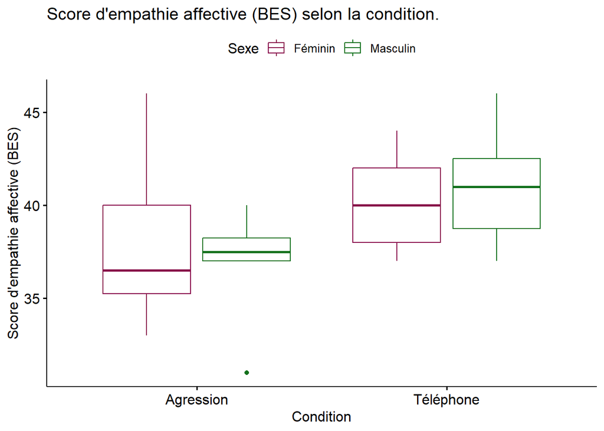

```r
ggboxplot(data, x = "Condition", y = "EAFF_BES", color = "Sexe",
          palette = c("#870A48", "#12711C"),
          ylab = "Score d'empathie affective (BES)",
          title = "Score d'empathie affective (BES) selon la condition.")
```

### b) Score d’empathie cognitive (BES)

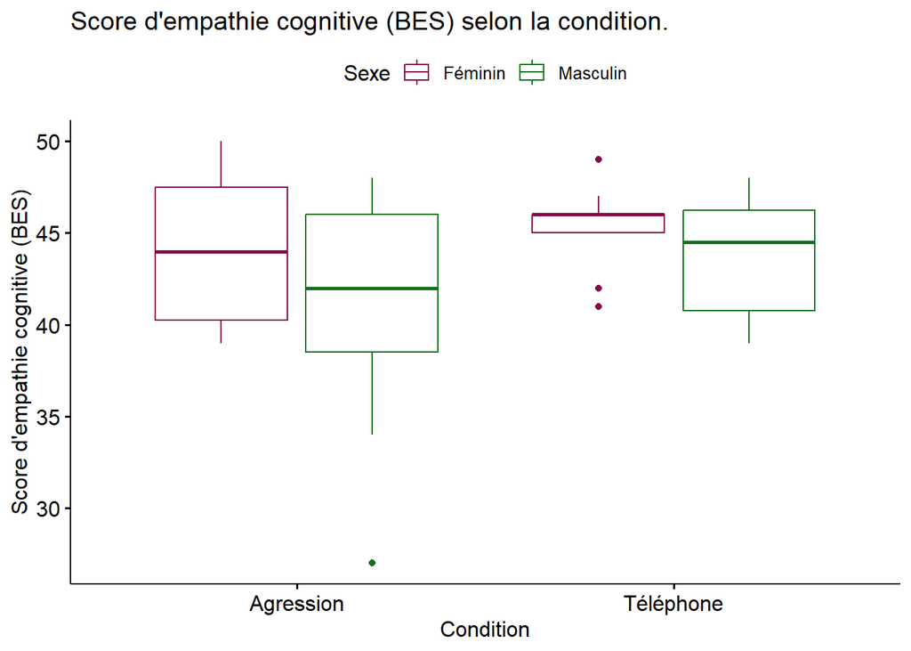

```r
ggboxplot(data, x = "Condition", y = "Ecog_BES", color = "Sexe",
          palette = c("#870A48", "#12711C"),
          ylab = "Score d'empathie cognitive (BES)",
          title = "Score d'empathie cognitive (BES) selon la condition.")
```

### c) Score de machiavélisme (DDS)

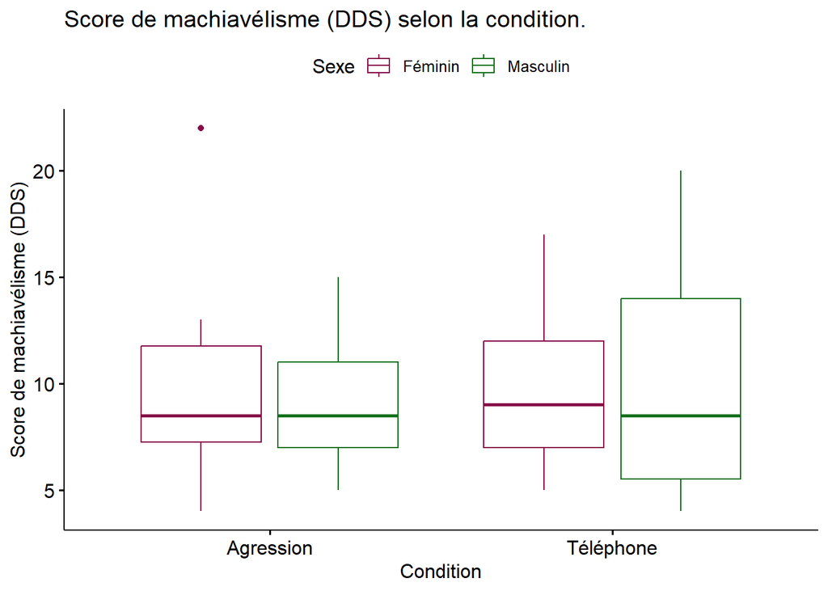

```r
ggboxplot(data, x = "Condition", y = "Machiavelisme_DDS", color = "Sexe",
          palette = c("#870A48", "#12711C"),
          ylab = "Score de machiavélisme (DDS)",
          title = "Score de machiavélisme (DDS) selon la condition.")
```

### d) Score de psychopathie (DDS)

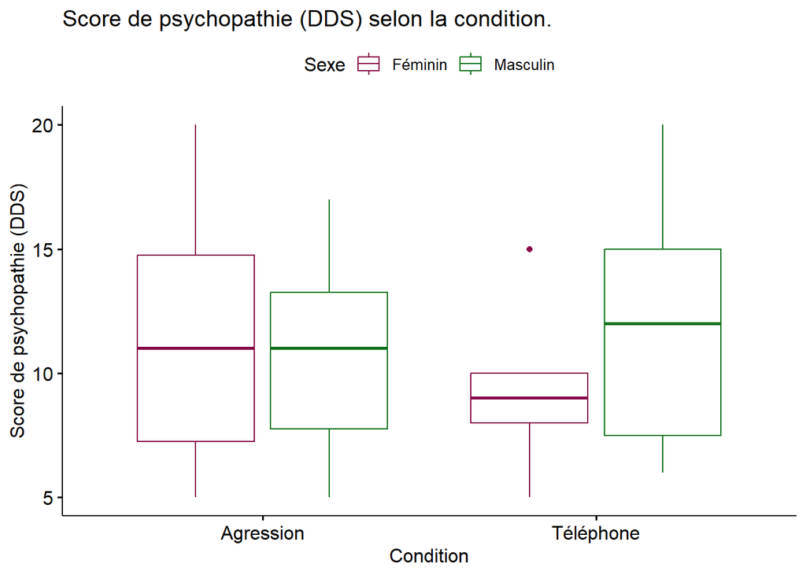

```r
ggboxplot(data, x = "Condition", y = "Psychopathie_DDS", color = "Sexe",
          palette = c("#870A48", "#12711C"),
          ylab = "Score de psychopathie (DDS)",
          title = "Score de psychopathie (DDS) selon la condition.")
```

### e) Score de narcissisme (DDS)

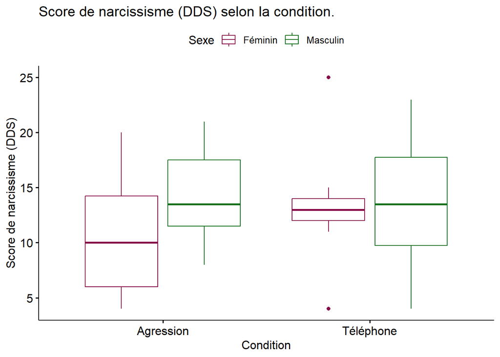

```r
ggboxplot(data, x = "Condition", y = "Narcissisme_DDS", color = "Sexe",
          palette = c("#870A48", "#12711C"),
          ylab = "Score de narcissisme (DDS)",
          title = "Score de narcissisme (DDS) selon la condition.")
```

### f) Niveau d’arousal (ADCL)

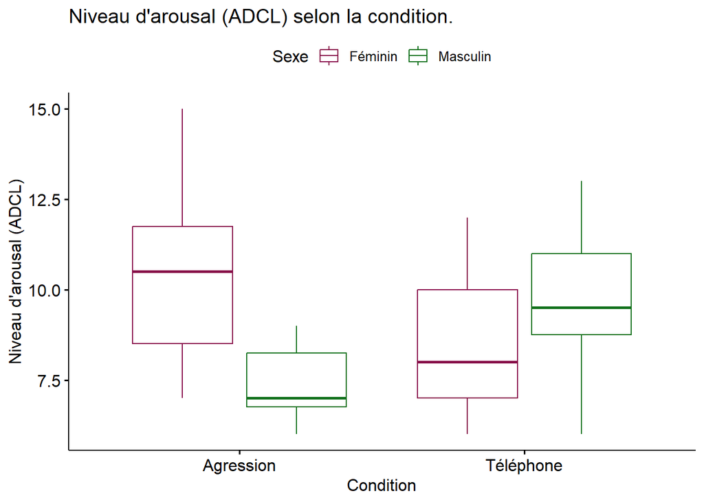

```r
ggboxplot(data, x = "Condition", y = "Excitation_ADCL", color = "Sexe",
          palette = c("#870A48", "#12711C"),
          ylab = "Niveau d'arousal (ADCL)",
          title = "Niveau d'arousal (ADCL) selon la condition.")
```

## 2. *Condition* et variables avec une corrélation supérieure à 40%

### a) Jambes à l’arrêt 2

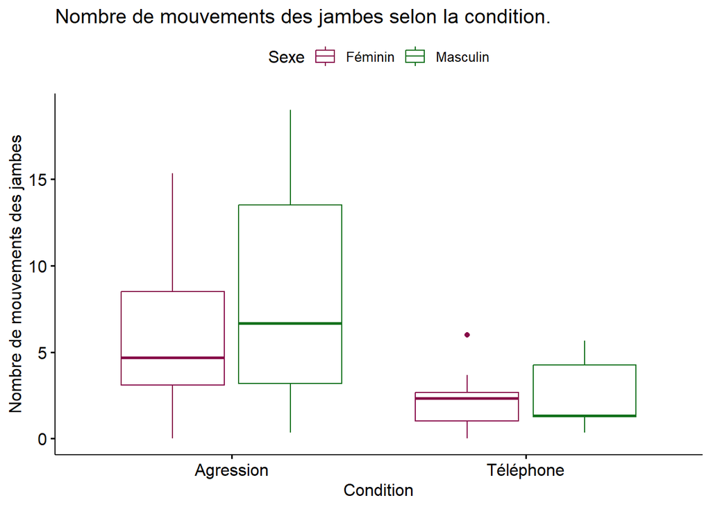

```r
ggboxplot(data, x = "Condition", y = "Jambes2", color = "Sexe",
          palette = c("#870A48", "#12711C"),
          ylab = "Nombre de mouvements des jambes",
          title = "Nombre de mouvements des jambes selon la condition.")
```

### b) Score Contagion Émotionelle (BES)

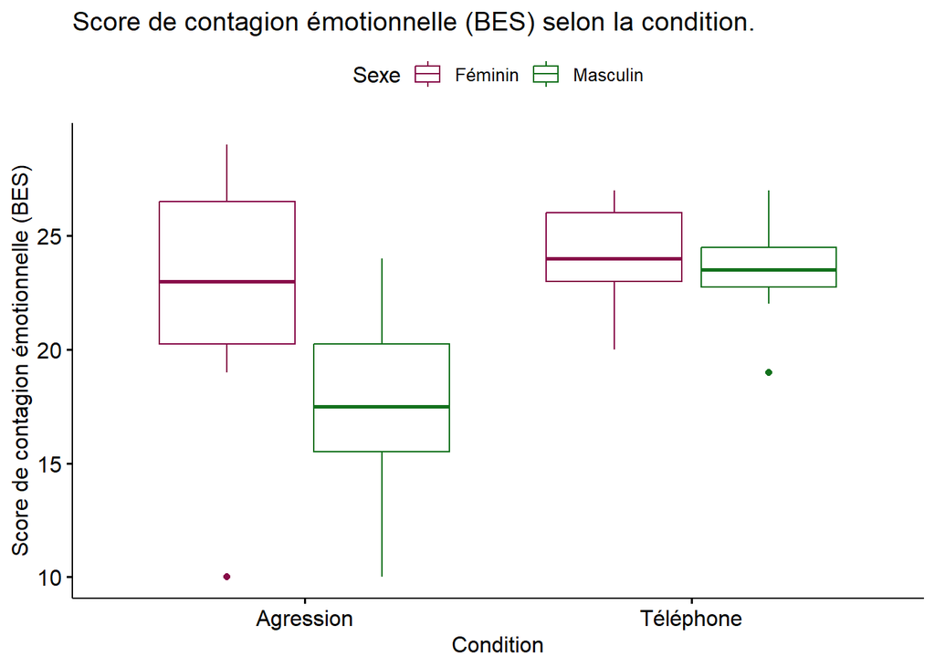

```r
ggboxplot(data, x = "Condition", y = "ContSc_BES", color = "Sexe",
          palette = c("#870A48", "#12711C"),
          ylab = "Score de contagion émotionnelle (BES)",
          title = "Score de contagion émotionnelle (BES) selon la condition.")
```